# Statistical Computing Homework

SA24204162

2024-12-5

## Homework1

### Exercise 3.4

#### Question

The Rayleigh density is
$$f(x)=\frac{x}{\sigma^2}e^{-x^2/(2\sigma^2)},x\geq
0,\sigma>0$$

Develop an aglorithm to generate random samples from a Rayleigh($\sigma$) distribution.Generate Rayleigh($\sigma$) samples for several choices of $\sigma>0$ and check that the mode of the generated samples is close to the theoretical mode $\sigma$(check the histogram).

#### Answer

$$F(x)=\int_{0}^{x}\frac{x}{\sigma^2}e^{-x^2/(2\sigma^2)}dx=1-e^{-\frac{x^2}{2\sigma^2}}$$
then
$$F^{-1}(u)=\sqrt{-2\sigma^2ln(1-u)},0\leq u\leq
1$$
,we can use inverse transform algorithm generate samples.

```r
Generate_Rayleign <- function(N,seed,sig){
set.seed(seed)
u <- runif(N)
x <- sqrt(-2*sig^2*log(1-u))
hist(x,probability = TRUE,main = paste('Empirical Density Graph of Rayleign Distribution--',sig))
y <- seq(0,8,0.01)
lines(y,y/(sig[1]^2) * exp(-y^2/(2*sig^2)) )
}
```

- $\sigma=0.1$

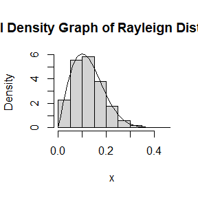

```r
seed = 123
N = 10000
sig <- seq(0.1,2,0.4)
Generate_Rayleign(N,seed,sig[1])
```

- $\sigma=0.5$

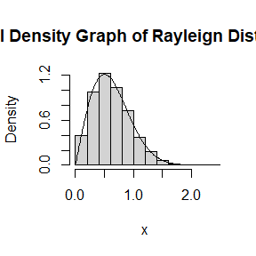

```r
Generate_Rayleign(N,seed,sig[2])
```

- $\sigma=0.9$

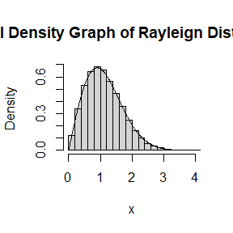

```r
Generate_Rayleign(N,seed,sig[3])
```

- $\sigma=1.3$

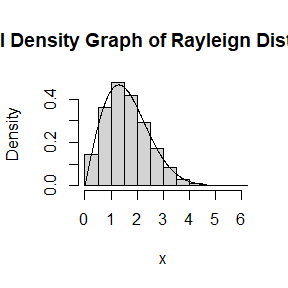

```r
Generate_Rayleign(N,seed,sig[4])
```

- $\sigma=1.7$

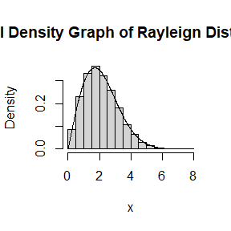

```r
Generate_Rayleign(N,seed,sig[5])
```

#### Conclusion

From the graph above,we can get that our algorithm behave robust for different choice of $\sigma$.when the parameter $\sigma$ become lager,the axis value x become more discrete.

### Exercise 3.11

#### Question

Generate a random sample of size 1000 from a normal location mixture.The components of the mixturre have $N(0,1)$ and $N(3,1)$,distributions with mixing probabilities $p_1$ and $p_2=1-p_1$.Graph the histogram of the sample with density superimposed,for $p_1=0.75$.Repeat with different values for $p_1$ and observe whether the empirical distribution of the mixture appears to be binodal.Make a conjecture about the values of $p_1$ that produce bimodal mixtures.

#### Answer

```r
theory_density <- function(p1,y){
  return(p1/sqrt(2*pi)*exp(-((y)^2)/(2))+(1-p1)/sqrt(2*pi)*exp(-((y-3)^2)/(2)))
}
```

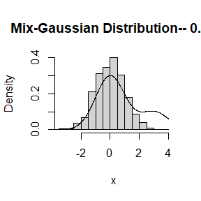

```r
set.seed(3)
N = 1000
p1 <- 0.75
x1 <- rnorm(N,0,1)
x2 <- rnorm(N,3,1)
p <- sample(c(1,0),1,prob = c(p1,1-p1))
x <- p*x1+(1-p)*x2
hist(x,probability = TRUE,main = paste('Mix-Gaussian Distribution--',p1))
y <- seq(-4,4,0.01)
lines(y,theory_density(p1,y))
```

```r
Generate_MixGaussian<- function(p1,N,seed){
set.seed(seed)
x1 <- rnorm(N,0,1)
x2 <- rnorm(N,3,1)
p <- sample(c(1,0),N,prob = c(p1,1-p1),replace = TRUE)
x <- p*x1+(1-p)*x2
hist(x,probability = TRUE,main = paste('Mix-Gaussian Distribution--',p1))
y <- seq(-8,8,0.01)
lines(y,theory_density(p1,y))
}
```

```r
p <- seq(0.1,0.9,0.1)
```

```r
for(i in 1:9){
Generate_MixGaussian(p[i],N,123)
}
```

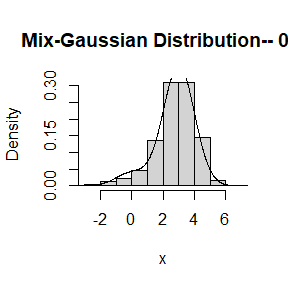

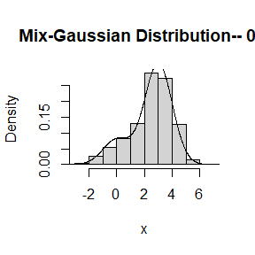

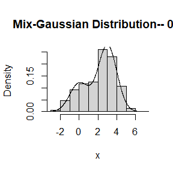

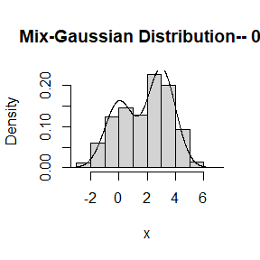

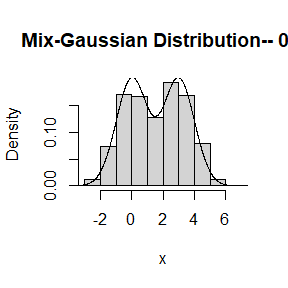

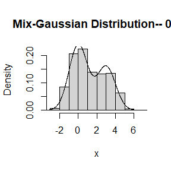

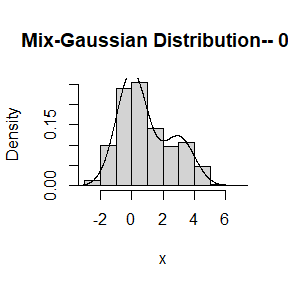

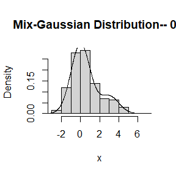

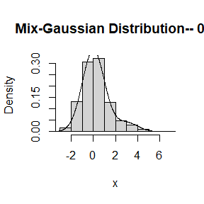

#### Conclusion

From the graph above,we find that the empirical distribution of the mixture appears to be binodal when $p_1$ is close to 0.5.

### Exercise 3.20

#### Question

A compound Poission process is a stochastic process $\{X(t),t\geq 0\}$ that can be represented as the random sum $X(t)=\sum_{i=1}^{N(t)}Y_i,t\geq 0$,where $\{N(t),t\geq 0\}$ is a Poission process and $Y_1,Y_2,\cdots$ are iid and indepedent of $\{N(t),t\geq 0\}$.Write a program to simulate a compound Poisson($\lambda$)-Gamma process ($Y$ has a Gamma distribution).Estimate the mean and the variance of $X(10)$ for several choices of the parameters and compare with the theoretical values.

#### Answer

```r
# Function to simulate the compound Poisson-Gamma process
Generate_compound_poisson_gamma <- function(lambda, k, theta, t, N) {
results <- numeric(N)

for (i in 1:N) {
# Simulate N(t), the number of events in time t, from Poisson distribution
    N_t <- rpois(1, lambda * t)

    # Simulate Y_i from Gamma distribution, shape = k, rate = theta
    if (N_t > 0) {
      Y <- rgamma(N_t, shape = k, rate = theta)
      results[i] <- sum(Y)  # X(t) = sum of the Y's
    } else {
      results[i] <- 0  # If N(t) = 0, X(t) = 0
    }
  }

  return(results)
}
```

```r
#parameters
t <- 10# Time point for X(t)
lambda <- c(1,3,5,10,20)# Rate of Poisson process
k <- c(1,5,10,20,100)# Shape parameter of Gamma distribution
theta <- c(1/2,1,3,10,20)# Rate parameter of Gamma distribution
N <- 10000# Number of simulations
```

```r
#Simalation
set.seed(123)
cat("Parameters Combination","Mean(Predict)","Mean(True)","Variance(Predict)","Variance(True)","Mean Error","Variance Error","\n")
```

```
## Parameters Combination Mean(Predict) Mean(True) Variance(Predict) Variance(True) Mean Error Variance Error
```

```r
for(i in 1:length(lambda)){
  for(j in 1:length(k)){
    for(l in 1:length(theta)){
      xt <- numeric(N)
      xt <-Generate_compound_poisson_gamma(lambda[i],k[j], theta[l], t, N)
      mean_hat <- mean(xt)
      var_hat <- var(xt)
      mean_true <- lambda[i] * t *(k[j]/theta[l])
      var_true <- lambda[i] * t *(((k[j]+k[j]^2)/(theta[l]^2)))
      value <- c(mean_hat,mean_true,var_hat,var_true)
      relative_error<-c(abs((mean_hat-mean_true)/mean_true),abs((var_hat-var_true)/var_true))
      cat("(",lambda[i],",",k[j],",",theta[l],"):",value,relative_error,"\n")
    }
  }
}
```

```
## ( 1 , 1 , 0.5 ): 20.15465 20 80.41633 80 0.007732332 0.00520413
## ( 1 , 1 , 1 ): 10.03192 10 20.09817 20 0.003191612 0.00490827
## ( 1 , 1 , 3 ): 3.349719 3.333333 2.274089 2.222222 0.004915709 0.02334003
## ( 1 , 1 , 10 ): 0.9944835 1 0.1958303 0.2 0.005516501 0.02084837
## ( 1 , 1 , 20 ): 0.4977533 0.5 0.04964641 0.05 0.004493443 0.007071705
## ( 1 , 5 , 0.5 ): 99.69828 100 1185.124 1200 0.003017239 0.01239648
## ( 1 , 5 , 1 ): 49.75231 50 300.9812 300 0.0049538 0.003270583
## ( 1 , 5 , 3 ): 16.62961 16.66667 32.83581 33.33333 0.00222369 0.01492556
## ( 1 , 5 , 10 ): 4.980557 5 3.015816 3 0.003888535 0.005271948
## ( 1 , 5 , 20 ): 2.516741 2.5 0.7642826 0.75 0.00669642 0.01904353
## ( 1 , 10 , 0.5 ): 199.4139 200 4333.255 4400 0.002930639 0.01516938
## ( 1 , 10 , 1 ): 99.81415 100 1082.79 1100 0.001858498 0.01564548
## ( 1 , 10 , 3 ): 33.48427 33.33333 123.6196 122.2222 0.004528015 0.01143314
## ( 1 , 10 , 10 ): 10.02505 10 11.16141 11 0.002504972 0.0146735
## ( 1 , 10 , 20 ): 5.009454 5 2.766917 2.75 0.001890784 0.00615176
## ( 1 , 20 , 0.5 ): 400.0184 400 17069.37 16800 4.604347e-05 0.01603417
## ( 1 , 20 , 1 ): 200.1397 200 4280.807 4200 0.0006984486 0.01923987
## ( 1 , 20 , 3 ): 67.02839 66.66667 466.5796 466.6667 0.005425792 0.0001865025
## ( 1 , 20 , 10 ): 19.98317 20 41.88085 42 0.0008416057 0.002836939
## ( 1 , 20 , 20 ): 9.982916 10 10.44565 10.5 0.001708449 0.005176033
## ( 1 , 100 , 0.5 ): 2001.478 2000 408059.8 404000 0.0007391974 0.01004895
## ( 1 , 100 , 1 ): 999.181 1000 101840.9 101000 0.0008190429 0.008326128
## ( 1 , 100 , 3 ): 331.8197 333.3333 10991.45 11222.22 0.004540755 0.02056346
## ( 1 , 100 , 10 ): 99.48316 100 997.0568 1010 0.005168423 0.0128151
## ( 1 , 100 , 20 ): 49.93955 50 251.2791 252.5 0.001209043 0.004835392
## ( 3 , 1 , 0.5 ): 60.00532 60 239.3907 240 8.866335e-05 0.002538752
## ( 3 , 1 , 1 ): 30.00159 30 59.25655 60 5.288982e-05 0.0123908
## ( 3 , 1 , 3 ): 10.03156 10 6.721371 6.666667 0.003155767 0.00820571
## ( 3 , 1 , 10 ): 2.994774 3 0.6071314 0.6 0.001742145 0.01188558
## ( 3 , 1 , 20 ): 1.498155 1.5 0.1486413 0.15 0.00123013 0.009057728
## ( 3 , 5 , 0.5 ): 300.3206 300 3538.946 3600 0.001068698 0.01695951
## ( 3 , 5 , 1 ): 149.911 150 881.9785 900 0.0005932577 0.02002387
## ( 3 , 5 , 3 ): 49.94104 50 98.58649 100 0.001179231 0.01413509
## ( 3 , 5 , 10 ): 14.98521 15 9.155753 9 0.0009856842 0.01730585
## ( 3 , 5 , 20 ): 7.492602 7.5 2.220337 2.25 0.0009864261 0.01318357
## ( 3 , 10 , 0.5 ): 602.4606 600 12852.17 13200 0.004101042 0.02635112
## ( 3 , 10 , 1 ): 299.6104 300 3312.624 3300 0.00129877 0.003825463
## ( 3 , 10 , 3 ): 99.84661 100 360.1248 366.6667 0.001533887 0.01784134
## ( 3 , 10 , 10 ): 29.961 30 33.05196 33 0.001300025 0.001574536
## ( 3 , 10 , 20 ): 14.96574 15 8.207554 8.25 0.002283971 0.005145018
```

[output cut: 70 more lines]

```
## ( 20 , 10 , 0.5 ): 3999.551 4000 90439.71 88000 0.0001121476 0.02772396
## ( 20 , 10 , 1 ): 1997.974 2000 21730.51 22000 0.001013082 0.01224972
## ( 20 , 10 , 3 ): 666.1688 666.6667 2416.013 2444.444 0.0007468379 0.01163094
## ( 20 , 10 , 10 ): 199.9549 200 223.7096 220 0.0002252734 0.01686167
## ( 20 , 10 , 20 ): 99.9616 100 55.81155 55 0.0003839699 0.01475539
## ( 20 , 20 , 0.5 ): 7996.62 8000 335299.5 336000 0.000422516 0.002084826
## ( 20 , 20 , 1 ): 3997.915 4000 82549.72 84000 0.0005212166 0.01726521
## ( 20 , 20 , 3 ): 1334.358 1333.333 9537.513 9333.333 0.0007687177 0.02187639
## ( 20 , 20 , 10 ): 399.6439 400 836.7308 840 0.0008902667 0.003891963
## ( 20 , 20 , 20 ): 199.9153 200 206.5324 210 0.0004232681 0.01651238
## ( 20 , 100 , 0.5 ): 40015 40000 8124890 8080000 0.0003749448 0.005555654
## ( 20 , 100 , 1 ): 19998.98 20000 2023518 2020000 5.07878e-05 0.001741378
## ( 20 , 100 , 3 ): 6669.92 6666.667 223431 224444.4 0.0004879869 0.004515347
## ( 20 , 100 , 10 ): 2000.622 2000 20420.04 20200 0.0003111729 0.01089298
## ( 20 , 100 , 20 ): 1000.41 1000 5102.913 5050 0.0004098531 0.01047785
```

#### Conclusion

From the result,we can get a conclusion that estimation error(relative error) is very small,and behave robust for choice of parameters.

## Homework2

### Complexity of Quicksort

#### Question

- For $n = 10^4, 2 × 10^4, 4 × 10^4, 6 × 10^4, 8 × 10^4$, apply the fast sorting algorithm to randomly permuted numbers of $1,\cdots,n$.
- Calculate computation time averaged over 100 simulations, denoted by $a_n$.
- Regress an on $t_n:= n log(n)$, and graphically show the results (scatter plot and regression line).

#### Answer

```r
#Quicksort Alogorithm Realization
Quicksort <- function(a){
  if (length(a)<=1) {
      return(a)
  }
  #select a bechmark element
  pivot <- a[1]
  left <- a[a<pivot]
  right <- a[a>pivot]
  #recursively use Quicksort function
  return(c(Quicksort(left),pivot,Quicksort(right)))
}
```

```r
#Test on Quicksort function
set.seed(124)
v <- c(2,3,4,6,3,-1,4,9)
Quicksort(v)
```

```
## [1] -1  2  3  4  6  9
```

```r
#Construct a function to compute the compution time
measure_sort_time <- function(n,simulations = 100){
  times <- replicate(simulations,{
    # Generate a random permutation of numbers from 1 to n
    perm <- sample(1:n)
    # Measure the sorting time via Quicksort
    start_time <- Sys.time()
    Quicksort(perm)
    end_time <- Sys.time()
    time <- end_time - start_time
    time
  })
  return(mean(times))
}
```

```r
n_values <- c(1,2,4,6,8)*10^4
# Calculate average sorting times
a_n <- sapply(n_values,measure_sort_time)
#Calculate tn
t_n <- n_values * log(n_values)
```

```r
df <- data.frame(
  t_n = t_n,
  a_n = a_n
)
fit <- lm(a_n~t_n,data= df)
summary(fit)
```

```
##
## Call:
## lm(formula = a_n ~ t_n, data = df)
##
## Residuals:
##          1          2          3          4          5
##  0.0010648 -0.0004953 -0.0006935 -0.0007487  0.0008727
##
## Coefficients:
##              Estimate Std. Error t value Pr(>|t|)
## (Intercept) 3.333e-03  8.429e-04   3.955   0.0289 *
## t_n         1.199e-07  1.550e-09  77.384 4.76e-06 ***
## ---
## Signif. codes:  0 '***' 0.001 '**' 0.01 '*' 0.05 '.' 0.1 ' ' 1
##
## Residual standard error: 0.00103 on 3 degrees of freedom
## Multiple R-squared:  0.9995, Adjusted R-squared:  0.9993
## F-statistic:  5988 on 1 and 3 DF,  p-value: 4.756e-06
```

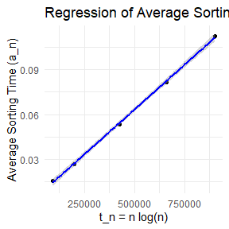

```r
#Regress Plot
# Plot scatter plot and regression line
ggplot(df, aes(x = t_n, y = a_n)) +
  geom_point() +
  geom_smooth(method = "lm", col = "blue") +
  labs(title = "Regression of Average Sorting Time on t_n",
       x = "t_n = n log(n)",
       y = "Average Sorting Time (a_n)") +
  theme_minimal()
```

#### Conclusion

Based on the regression output, the regression effect is significant, and the regression plot also shows a good fit. Therefore, through our numerical simulation method for verification, we can indeed conclude that the quicksort algorithm has an average time complexity of $O(n \log n)$.

### Exercise 5.4

#### Question

Write a function to compute a Monte Carlo estimate of the Beta(3,3) cdf,and use the function to estimate $F(x)$ for $x=0.1,0.2,\cdots,0.9$.Compute the estimates with the values returned by the pbeta function in R.

#### Answer

```r
#A function of estimate for Beta(3,3)
BetaF_estimate <- function(x,seed=123,N=10000){
  set.seed(seed)
  X <- numeric(N)
  X <- rbeta(N,3,3)
  return(sum(X<x)/N)
}
```

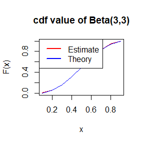

```r
#Get an estimate via Monte Carlo
x_values <- seq(0.1,0.9,0.1)
F_estimate <- sapply(x_values,BetaF_estimate)
#Generate value via pbeta function
F_theory <- pbeta(x_values,3,3)
#Compare the theory and simulation result
plot(x_values,y = F_estimate,type = 'l',col = 'red',
     main = 'cdf value of Beta(3,3)',xlab = 'x',ylab = 'F(x)')
lines(x_values,y=F_theory,col = 'blue')
legend('topleft',col = c('red','blue'),lty = c(1,1),
       lwd = c(2,2),legend = c('Estimate','Theory'))
```

### Exercise 5.9

#### Question

The Rayleigh density is
$$f(x)=\frac{x}{\sigma^2}e^{-x^2/(2\sigma^2)},x\geq0,\sigma>0.$$
Implement a function to generate samples from a Rayleigh($\sigma$) distribution,using antithetic varibles.What is the percent reduction in variance of $\frac{X+X^{'}}{2}$ compared with $\frac{X_1+X_2}{2}$ for indepedent $X_1,X_2$?

#### Answer

```r
#density function of rayleigh
f <- function(sig,x){
  return(x/(sig^2)*exp(-x^2/(2*sig^2)))
}
```

```r
#Generate Rayleign distribution via Inverse transformation
Generate_Rayleign <- function(sig,u,seed = 123){
set.seed(seed)
u1 <- u[1:(length(u)/2)]
u2 <- u[(length(u)/2+1):(length(u))]
x1 <- sqrt(-2*sig^2*log(1-u1))
x2 <- sqrt(-2*sig^2*log(1-u2))
x <- (as.vector(x1) + as.vector(x2))/2
return(x)
}
```

```r
#antithetic variables
N = 10000
U1 <- runif(N/2,0,1)
u <- c(U1,1-U1)
sig_values <- seq(0.1,2,0.4)
A <- matrix(0,nrow = 3,ncol = length(sig_values))
rownames(A) <- c('anti_variance','simple_variance','reduction percent')
colnames(A) <- sig_values
count <- 1
for(sig in sig_values){
  x <- Generate_Rayleign(sig,u)
  var_anti <- var(x)
  A[1,count] <- var_anti
  count <- count + 1
}

#simple variables
u <- runif(N)
count <- 1
for(sig in sig_values){
  x <- Generate_Rayleign(sig,u)
  var_simple <- var(x)
  A[2,count] <- var_simple
  count <- count + 1
}
A[3,] <- (A[2,]-A[1,])/A[2,]
A
```

```
##                           0.1         0.5         0.9        1.3        1.7
## anti_variance     0.000114925 0.002873126 0.009308927 0.01942233 0.03321333
## simple_variance   0.002046931 0.051173272 0.165801400 0.34593132 0.59156302
## reduction percent 0.943854953 0.943854953 0.943854953 0.94385495 0.94385495
```

#### Conclusion

From the result above,we can conclude that the variance of antithetic variable reduce approximate 94% compare with the simple variable(indepedent).At the same time,this result behaves robust for different choices of parameter $\sigma$.

### Exercise 5.13

#### Question

Find two importance functions $f_1$ and $f_2$ that are supported on $(0,\infty)$ and are ‘close’ to
$$g(x)=\frac{x^2}{\sqrt{2\pi}}e^{-x^2/2},x>1.$$
Which of your two importance functions should produce the smaller variance in estimating
$$\int_{1}^{\infty}\frac{x^2}{\sqrt{2\pi}}e^{-x^2/2}dx$$
by importance sampling?Explain. #### Answer

```r
g <- function(x){
  return(x^2/sqrt(2*pi)*exp(-x^2/2)) * (x>1)
}
f3 <- function(x) x^2
```

- the first importance functions use $x\sim N(0,1),x>1$
- the second importance function use $N(3,0.5^2),x>1$
- the third importance function use $x^2,x>1$

```r
#Estimate the integral via importance sampling
set.seed(123)
N <- 10000
replica <- 1000
estimate_f1 <- numeric(replica)
estimate_f2 <- numeric(replica)
estimate_f3 <- numeric(replica)
for(i in 1:replica){
  sample_1 <- rnorm(N,0,1)
  sample_2 <- rnorm(N,3,0.5)
  u <- runif(N)
  sample_3 <- (3*u)^{1/3}
  estimate_f1[i] <- mean(g(sample_1)/dnorm(sample_1)*(sample_1>1))
  estimate_f2[i] <- mean(g(sample_2)/dnorm(sample_2,3,0.5)*(sample_2>1))
  estimate_f3[i] <- mean(g(sample_3)/f3(sample_3)*(sample_3>1))
}
cat('the mean and variance of f1:',mean(estimate_f1),",",var(estimate_f1),'\n')
```

```
## the mean and variance of f1: 0.4010488 , 0.0001339638
```

```r
cat('the mean and variance of f2:',mean(estimate_f2),",",var(estimate_f2),'\n')
```

```
## the mean and variance of f2: 0.4020189 , 0.003246173
```

```r
cat('the mean and variance of f3:',mean(estimate_f3),",",var(estimate_f3),'\n')
```

```
## the mean and variance of f3: 0.1226257 , 8.096703e-07
```

```r
integrand <- function(x) (x^2 / sqrt(2 * pi)) * exp(-x^2 / 2)

true_value <- integrate(integrand, 1, Inf)$value
true_value
```

```
## [1] 0.400626
```

#### Conclusion

From the result above,two normal distribution have smaller bias,and standard norm distribution have lower bias and variance than the other normal distribution $N(3,0.5^2)$(**It is coincide with our intuition,because the standard normal density is more likely to the goal function**).At the same time,$f(x)=x^2$ have smallest variance but it has very large bias,which means that it is not a good function to estimate our goal integral(**although they have a same term $x^2$,but the value of goal function have larger difference with it**).

## Homework3

### Exercises 6.6

#### Question

Estimate the 0.025,0.05,0.95,and 0.975 quantiles of the skewness $\sqrt{b_1}$ under normality by a Monte Carlo experiment.Compute the standard error of the estimates from (2.14) using the normal approximation for the density (with exact variance formula).Compare the estimated quantiles with the quantiles of the large sample approximation $\sqrt{b_1}\approx N(0,6/n).$

#### Answer

The variance of the q sample quantile is
$$Var(\hat{x_q})=\frac{q(1-q)}{nf(x_q)^2}$$

```r
library(e1071)
library(MASS)
```

```r
#Generate data
Generate_skewness <- function(sample_size,mean,se){
  x <- rnorm(sample_size,mean,se)
  skewness_values <- skewness(x)
  return(skewness_values)
}
```

```r
#statistical inference
Skewness_quantiles <- function(skewness_values,quantile_value,mean,se){
  quantiles <- quantile(skewness_values, probs = quantile_value)
  variances <- quantile_value * (1-quantile_value)/(length(skewness_values)*dnorm(quantiles,mean,se))
  SE <- sqrt(variances)
  return(c(quantiles,SE))
}
```

```r
#result reporting
Skewness_Result <- function(quantile.hat,quantile.se,quantile_values,sample_size){
  #Generate large sample approximation of quantile
  approx_quantiles <- qnorm(quantile_values, mean = 0, sd = sqrt(6/sample_size))
  table <- matrix(c(quantile.hat, quantile.se, approx_quantiles), nrow = 3, byrow = TRUE)

#rename the matrix
rownames(table) <- c("quantile(estimate)", "quantile(sd)", "quantile(theory)")
colnames(table) <- quantile_values

# output the result
print(table)
}
```

```r
set.seed(123)
m <- 1e4
n <- 1e3
mean <- 0
se <- 1
quantile_values <- c(0.025,0.05,0.95,0.975)
Skw <- numeric(m)
quantile.hat <- quantile.se <- numeric(length(quantile_values))
for(i in 1:m){
  Skw[i] <- Generate_skewness(sample_size=n,mean=mean,se=se)
}

for(j in 1:length(quantile_values)){
  quantile.hat[j] <- Skewness_quantiles(Skw,quantile_values[j],mean,se)[1]
  quantile.se[j] <- Skewness_quantiles(Skw,quantile_values[j],mean,se)[2]
}
Skewness_Result(quantile.hat,quantile.se,quantile_values,n)
```

```
##                           0.025        0.05       0.95      0.975
## quantile(estimate) -0.153400461 -0.12632189 0.12512550 0.15007675
## quantile(sd)        0.002486407  0.00346437 0.00346411 0.00248578
## quantile(theory)   -0.151818157 -0.12740981 0.12740981 0.15181816
```

```r
set.seed(123)
m <- 1e4
n <- 10
mean <- 0
se <- 1
quantile_values <- c(0.025,0.05,0.95,0.975)
Skw <- numeric(m)
quantile.hat <- quantile.se <- numeric(length(quantile_values))
for(i in 1:m){
  Skw[i] <- Generate_skewness(sample_size=n,mean=mean,se=se)
}

for(j in 1:length(quantile_values)){
  quantile.hat[j] <- Skewness_quantiles(Skw,quantile_values[j],mean,se)[1]
  quantile.se[j] <- Skewness_quantiles(Skw,quantile_values[j],mean,se)[2]
}
Skewness_Result(quantile.hat,quantile.se,quantile_values,n)
```

```
##                           0.025         0.05        0.95       0.975
## quantile(estimate) -0.971644469 -0.811599545 0.815198203 0.986373571
## quantile(sd)        0.003129831  0.004068259 0.004074217 0.003152478
## quantile(theory)   -1.518181574 -1.274098141 1.274098141 1.518181574
```

#### Conclusion

From the result above,we conclude that Estimate quantiles with Monte Carlo method is nearly same with the large sample approximation.However,if sample size $n$ is small,they will have some differences.For example,if we set sample size is equal to 10,they have significant differences between MC estimators and large sample estimators because of large sample condition is failed.

### Exercise 6.B

#### Question

Tests for association based on Pearson product moment correlation $\rho$, Spear- man’s rank correlation coefficient $\rho_s$, or Kendall’s coefficient $\tau$ , are implemented in cor.test. Show (empirically) that the nonparametric tests based on $\rho_s$ or $\tau$ are less powerful than the correlation test when the sampled distribution is bivariate normal. Find an example of an alternative (a bivariate distribution $(X,Y)$ such that $X$ and $Y$ are dependent) such that at least one of the nonparametric tests have better empirical power than the correlation test against this alternative.

#### Answer

```r
#Generate data
Generate_biogauss <- function(sample_size,mu,sigma){
  data_normal <- mvrnorm(sample_size, mu, sigma)
  x_normal <- data_normal[, 1]
  y_normal <- data_normal[, 2]
  return(list(x=x_normal,y=y_normal))
}

Generate_alternative <- function(sample_size){
  x_dep <- rnorm(sample_size)
  y_dep <- sqrt(abs(x_dep)) + rnorm(sample_size, sd = 0.1)  # create dependent relationship
  return(list(x=x_dep,y=y_dep))
  }
```

```r
#Statistical Inference
Compare_Test <- function(x,y){
  pearson_result <- cor.test(x, y)
  spearman_result <- cor.test(x, y, method = "spearman")
  kendall_result <- cor.test(x, y, method = "kendall")
  return(list(p=pearson_result,s=spearman_result,k=kendall_result))
}
```

```r
#result reporting
Correlation_Result <-function(normal,alternative){
  normal_value <- c(normal$p$p.value,normal$s$p.value,normal$k$p.value)
  alternative_value <- c(alternative$p$p.value,alternative$s$p.value,alternative$k$p.value)
table <- matrix(c(normal_value,alternative_value),byrow = T,nrow = 2)
#rename the matrix
rownames(table) <- c("normal condition", "other condition")
colnames(table) <- c('pearson','spearman','kendall')

# output the result
print(table)
}
```

```r
#Experiment procedure
## parameter settings
set.seed(123)
n <- 10
mu <- c(0,0)
sigma <- matrix(c(1,0.8,0.8,1),2,2)
rnormal <- Generate_biogauss(n,mu,sigma)
ralternative <- Generate_alternative(n)
normal <- Compare_Test(rnormal$x,rnormal$y)
alternative <- Compare_Test(ralternative$x,ralternative$y)
Correlation_Result(normal,alternative)
```

```
##                      pearson    spearman    kendall
## normal condition 0.003223048 0.008235571 0.01666612
## other condition  0.297035596 0.178219329 0.15574184
```

#### Conclusion

From the results above, it can be seen that, in terms of power, the correlation test has optimal power under normality. However, if the normality assumption is not met, the other two tests exhibit better power.

### Powers test

#### Question

- If we obtain the powers for two methods under a particular simulation setting with 10,000 experiments: say, 0.651 for one method and 0.676 for another method. We want to know if the powers are different at 0.05 level.
- What is the corresponding hypothesis test problem?
- What test should we use? Z-test, two-sample t-test, paired-t test or McNemar test? Why?
- Please provide the least necessary information for hypothesis testing

#### Answer

To answer the question step by step:

##### 1. **What is the corresponding hypothesis test problem?**

- **Null hypothesis ($H_0$))**: The powers of the two methods are not significantly different, i.e., $( \text{Power}_1 = \text{Power}_2 )$.
- **Alternative hypothesis ($H_A$))**: The powers of the two methods are significantly different, i.e., $( \text{Power}_1 \neq \text{Power}_2 )$.

We want to test whether the power values (0.651 and 0.676) are significantly different at the 0.05 significance level.

##### 2. **What test should we use?**

- **McNemar’s test** is used for paired binary data, such as correct vs incorrect classifications, and is not applicable here.
- **Z-test**: Since we are comparing two proportions (power estimates) from large samples (10,000 experiments), a **two-proportion Z-test** is appropriate. The power is based on a large number of simulations, and a Z-test can compare two proportions.
- **Two-sample t-test** is used for comparing means of independent samples, but we are comparing proportions, not means.
- **Paired t-test** is used for dependent samples with continuous data, which is not relevant here.

Therefore, the **Z-test** is the most suitable method because we are comparing two proportions derived from large independent samples. The test will determine if the difference in powers is statistically significant.

##### 3. **What is the least necessary information for hypothesis testing?**

For the hypothesis test, we need: - The two power estimates: $\hat{p}_1 = 0.651$ and $\hat{p}_2 = 0.676$. - The sample sizes for both methods: $n_1 = n_2 = 10,000$. - The significance level: $\alpha = 0.05$.

##### 4. **Steps for the Z-test**

For the two-proportion Z-test, the formula is:
$$Z = \frac{ \hat{p}_1 - \hat{p}_2 }{\sqrt{\hat{p}(1-\hat{p})
\left(\frac{1}{n_1} + \frac{1}{n_2}\right)}}$$
Where $\hat{p}$ is the pooled proportion, calculated as:
$$\hat{p} = \frac{\hat{p}_1 n_1 + \hat{p}_2 n_2}{n_1 + n_2}$$

Once we compute the Z-value, you can compare it against the critical value from the standard normal distribution or calculate the p-value. If the p-value is less than 0.05, you reject the null hypothesis, indicating a significant difference in power between the two methods.

## Homework4

### Comparation of Bonferroni correction and B-H correction

#### Question

Of $N = 1000$ hypotheses, 950 are null and 50 are alternative. The p-value under any null hypothesis is uniformly distributed (use runif), and the p-value under any alternative hypothesis follows the beta distribution with parameter 0.1 and 1 (use rbeta). Obtain Bonferroni adjusted p-values and B-H adjusted p-values. Calculate FWER, FDR, and TPR under nominal level $\alpha=0.1$ for each of the two adjustment methods based on $m = 10000$ simulation replicates. You should output the 6 numbers (3) to a 3 × 2 table (column names: Bonferroni correction, B-H correction; row names: FWER, FDR, TPR). Comment the results.

#### Answer

```r
#data generation
data_generation1 <- function(N0,N1){
  p_null <- runif(N0)                            # Null hypotheses
  p_alt <- rbeta(N1, 0.1, 1)                     # Alternative hypotheses
  p_values <- c(p_null, p_alt)
  return(p_values)
}
```

```r
# Statistical Inference
statistical_inference1 <- function(p_values,alpha,N0,N1){
  # Bonferroni correction
  bonf_rejected <- (p.adjust(p_values, method = "bonferroni") < alpha)
  # Benjamini-Hochberg correction
  bh_rejected <- (p.adjust(p_values, method = "BH") < alpha)

  # Functions to calculate FWER, FDR, TPR
calc_metrics <- function(rejected, true_alt) {
  FWER <- as.numeric(sum(rejected[1:N0])>0)   # FWER: At least one false rejection
  FDR <- sum(rejected[1:N0]) / max(1, sum(rejected))
  TPR <- sum(rejected[(N0 + 1):(N0+N1)]) / N1
  return(c(FWER = FWER, FDR = FDR, TPR = TPR))
}

  # Update metrics for Bonferroni correction
  bonf_metrics <- calc_metrics(bonf_rejected, true_alt = p_values[(N0+1):(N0+N1)])


  # Update metrics for B-H correction
  bh_metrics <- calc_metrics(bh_rejected, true_alt = p_values[(N0+1):(N0+N1)])
  return(list(bonf_metrics=bonf_metrics,bh_metrics=bh_metrics))
}
```

```r
#Result Reporting
result_reporting1 <- function(results,bonf_metrics,bh_metrics,m){

# Store averages of metrics
  results[,1 ] <- results[,1 ] + bonf_metrics/m
  results[,2 ] <- results[,2] + bh_metrics /m
  return(results)
}
```

```r
set.seed(123)

# Simulation parameters
N <- 1000      # Total number of hypotheses
N0 <- 950        # Number of null hypotheses
N1 <- N - N0     # Number of alternative hypotheses
m <- 10000       # Number of simulation replicates
alpha <- 0.1     # Nominal significance level
# Storing results
  results <- matrix(0, nrow = 3, ncol = 2)
  colnames(results) <- c("Bonferroni correction", "B-H correction")
  rownames(results) <- c("FWER", "FDR", "TPR")

for (i in 1:m) {
  p_values <- data_generation1(N0,N1)

  bonf_metrics <- statistical_inference1(p_values,alpha,N0,N1)$bonf_metrics
  bh_metrics <- statistical_inference1(p_values,alpha,N0,N1)$bh_metrics

  results <- result_reporting1(results,bonf_metrics,bh_metrics,m)

}

print(results)
```

```
##      Bonferroni correction B-H correction
## FWER           0.087300000     0.93050000
## FDR            0.004510088     0.09502215
## TPR            0.396736000     0.56106200
```

#### Conclusion

From the table above,we can see:

- Bonferroni correction: Tends to be more conservative, aiming to control FWER at the cost of TPR.
- B-H correction: More powerful (higher TPR) but may allow a higher FDR, as it targets the false discovery rate instead of FWER.

### Exericise 7.4

#### Question

Refer to the air-conditioning data set aircondit provided in the boot package.The 12 observations are the times in hours between faliures of air-conditioning equipment[63,Example 1.1]:
$$3,5,7,18,43,85,91,98,100,130,230,487$$
Assume that the times between failures follow an exponential model $Exp(\lambda)$.Obtain the MLE of the hazard rate $\lambda$ and use bootstrap to estimate the bias and standard error of the estimate.

#### Answer

As we all know,the MLE estimate of hazard rate $\lambda$ is:
$$\hat{\lambda}=1/\bar{x}$$
where $\bar{x}$ is the mean of the failure times.

```r
#loading package
library(boot)
```

```r
#data generation
data_generation2 <- function(){
  # Air-conditioning failure times data
  failure_times <- c(3, 5, 7, 18, 43, 85, 91, 98, 100, 130, 230, 487)
  return(failure_times)
}
```

```r
#statistical inference
statistical_inference2 <- function(data,Repetitions){
  # Function to compute MLE of lambda for bootstrap samples
  lambda_mle_fn <- function(data, indices) {
  resampled_data <- data[indices]
  return(1 / mean(resampled_data))
}

  # Perform bootstrap
  bootstrap_results <- boot(data = data, statistic = lambda_mle_fn, R = Repetitions)
  return(bootstrap_results)
}
```

```r
#result reporting
result_reporting2 <- function(lambda_mle,bootstrap_results){
  # Extract bias and standard error
  lambda_mle_bias <- mean(bootstrap_results$t) - lambda_mle
  lambda_mle_se <- sd(bootstrap_results$t)
  # Output the results
  cat("MLE of lambda:", lambda_mle, "\n")
  cat("Bootstrap estimate of bias:", lambda_mle_bias, "\n")
  cat("Bootstrap estimate of standard error:", lambda_mle_se, "\n")
  cat('Relative Error of Estimate:',abs(lambda_mle_bias)/lambda_mle*100,'%')
}
```

```r
#Experimental Settings
set.seed(123)
Repetitions <- 1000
data <- data_generation2()
# MLE of lambda
lambda_mle <- 1 / mean(data)

bootstrap_results <- statistical_inference2(data,Repetitions)
result_reporting2(lambda_mle,bootstrap_results)
```

```
## MLE of lambda: 0.00925212
## Bootstrap estimate of bias: 0.00151119
## Bootstrap estimate of standard error: 0.004217765
## Relative Error of Estimate: 16.33344 %
```

#### Conclusion

From the result above,we concluded that bootstrap method has approximate 16.3% relative error rate,which is not low or high enough.

### Exericise 7.5

#### Question

Refer to Exercise 7.4.Compute 95% bootstrap confidence intervals for the mean time between failures $1/\lambda$ by the standard normal,basic,percentile,and BCa methods.Compare the intervals and explain why they may differ.

#### Answer

```r
#statistical inference
statistical_inference3 <- function(data,Repetitions,alpha){
  # Function to compute MLE of 1/lambda for bootstrap samples
  lambda_mle_fn2 <- function(data, indices) {
  resampled_data <- data[indices]
  return(mean(resampled_data))
}

  # Perform bootstrap
  bootstrap_results <- boot(data = data, statistic = lambda_mle_fn2, R = Repetitions)
  ci <- boot.ci(bootstrap_results,type=c("norm","basic","perc","bca"),conf = alpha)
  return(ci)
}
```

```r
#result reporting
result_reporting3 <- function(lambdad_mle,norm_ci,basic_ci,perc_ci,BCa_ci){
  # Output results
  mu <- 1 / lambda_mle
  cat("Mean time between failures:", mu, "\n")
cat("Normal CI:(",norm_ci[1],',',norm_ci[2],')', "\n")
cat("Basic CI:(",basic_ci[1],',',basic_ci[2],')', "\n")
cat("Percentile CI:(",perc_ci[1],',',perc_ci[2],')', "\n")
cat("BCa CI:(",BCa_ci[1],',',BCa_ci[2],')', "\n")

}
```

```r
#Experimental Settings
alpha <- 0.95
m <- 1000
Repetitions <- 1000

ci.norm<-ci.basic<-ci.perc<-ci.bca<-matrix(NA,m,2)
for(i in 1:m){
ci <- statistical_inference3(data,Repetitions,alpha)
ci.norm[i,]<-ci$norm[2:3];ci.basic[i,]<-ci$basic[4:5]
ci.perc[i,]<-ci$percent[4:5];ci.bca[i,]<-ci$bca[4:5]
}

norm_ci <- c(mean(ci.norm[,1]),mean(ci.norm[,2]))
basic_ci <- c(mean(ci.basic[,1]),mean(ci.basic[,2]))
perc_ci <- c(mean(ci.perc[,1]),mean(ci.perc[,2]))
BCa_ci <- c(mean(ci.bca[,1]),mean(ci.bca[,2]))

result_reporting3(lambda_mle,norm_ci,basic_ci,perc_ci,BCa_ci)
```

```
## Mean time between failures: 108.0833
## Normal CI:( 34.35325 , 181.8475 )
## Basic CI:( 24.69839 , 169.4745 )
## Percentile CI:( 46.69213 , 191.4683 )
## BCa CI:( 56.97844 , 228.2832 )
```

#### Conclusion

Explanation of the Methods:

```
Normal Method: Uses the mean of the bootstrap estimates and the standard deviation to create a CI based on the normal distribution.

Basic Method: Computes the CI based on the distribution of the bootstrap estimates.

Percentile Method: Directly uses the quantiles of the bootstrap estimates to form the CI.

BCa (Bias-Corrected and Accelerated) Method: Adjusts for both bias and skewness in the bootstrap distribution, providing a more accurate CI.
```

Comparison of Intervals:

[output not shown]

## Homework5

### Exercises 7.8

#### Question

Refer to Exercise 7.7. Obtain the jackknife estimates of bias and standard error of $\hat{\theta}$.

#### Answer

```r
library(bootstrap)
library(DAAG)
#generating data
scor_generate <- function(){
  data(scor)
  return(scor)
}
```

```r
#statistical inference
jackknife_infer <- function(data){
  # Jackknife 方法
  n <- nrow(data)
  theta_jackknife <- numeric(n)

  for (i in 1:n) {
    # 排除第 i 个观测
    data_excluded <- data[-i, ]
    Sigma_hat_i <- cov(data_excluded)
    eigenvalues_i <- eigen(Sigma_hat_i)$values
    lambda_hat_i <- sort(eigenvalues_i, decreasing = TRUE)

    # 计算每次排除的theta
    theta_jackknife[i] <- lambda_hat_i[1] / sum(lambda_hat_i)
  }

  return(theta_jackknife)
}
```

```r
#result reporting
jackknife_report <- function(data,theta_jackknife){
  n <- nrow(data)
  # 计算协方差矩阵的MLE
  Sigma_hat <- cov(data)

  # 计算协方差矩阵的特征值
  eigenvalues <- eigen(Sigma_hat)$values
  lambda_hat <- sort(eigenvalues, decreasing = TRUE)

  # 计算样本估计的theta
  hat_theta <- lambda_hat[1] / sum(lambda_hat)
  # 计算 Jackknife 偏差和标准误
  bias_theta <- (n - 1) * (mean(theta_jackknife) - hat_theta)
  se_theta <- sqrt((n - 1) / n * sum((theta_jackknife - mean(theta_jackknife))^2))
  cat('the jackknife estimates of theta is',(n-1) * mean(theta_jackknife),'\n')
  cat('the jackknife estimates of bias is',bias_theta,'\n')
  cat('the jackknife estimates of standard error is',se_theta,'\n')
}
```

```r
data <- scor_generate()
theta_jackknife <- jackknife_infer(data)
jackknife_report(data,theta_jackknife)
```

```
## the jackknife estimates of theta is 53.86408
## the jackknife estimates of bias is 0.001069139
## the jackknife estimates of standard error is 0.04955231
```

#### Conclusion

From the result above,we will conclude that the estimate bias of jackknife is very small.At the same time,standard error is small enough too.

### Exercise 7.10

#### Question

In Example 7.18, leave-one-out (n-fold) cross validation was used to select the best fitting model. Repeat the analysis replacing the Log-Log model with a cubic polynomial model. Which of the four models is selected by the cross validation procedure? Which model is selected according to maximum adjusted $R^2$?

#### Answer

```r
#data generating
ironslag_generate <- function(){
  attach(ironslag)

  data <- list(chemical=chemical,magnetic=magnetic)
  detach(ironslag)
  return(data)
}
```

Cubic polynomial model is
$$Y =
\beta_0+\beta_1X+\beta_2X^2+\beta X^3+\epsilon$$

```r
#Statistical inference
Cross_Validation <- function(chemical,magnetic){
  n <- length(magnetic)
  e1 <- e2 <- e3 <- e4 <- numeric(n)

  #for n-fold cross validation
  #fit models on leave-one-out samples
  for(k in 1:n){
    x <- chemical[-k]
    y <- magnetic[-k]

    J1 <- lm(y ~ x)
    yhat1 <- J1$coef[1] + J1$coef[2] * chemical[k]
    e1[k] <- magnetic[k] - yhat1

    J2 <- lm(y ~ x + I(x^2))
    yhat2 <- J2$coef[1] + J2$coef[2] * chemical[k]+J2$coef[3] * chemical[k]^2
    e2[k] <- magnetic[k] - yhat2

    J3 <- lm(log(y) ~ x )
    logyhat3 <- J3$coef[1] + J3$coef[2] * chemical[k]
    yhat3 <- exp(logyhat3)
    e3[k] <- magnetic[k] - yhat3

    J4 <- lm(y ~ poly(x, 3, raw = TRUE))
    yhat4 <- J4$coef[1] + J4$coef[2] * chemical[k] + J4$coef[3] * chemical[k]^2+ J4$coef[4] * chemical[k]^3
    e4[k] <- magnetic[k] - yhat4
  }
  mse <- c(mean(e1^2),mean(e2^2),mean(e3^2),mean(e4^2))
  x <- chemical
  y <- magnetic
  J1 <- lm(y ~ x)
  J2 <- lm(y ~ x + I(x^2))
  J3 <- lm(log(y) ~ x )
  J4 <- lm(y ~ poly(x, 3, raw = TRUE))
  model_result <- list(mse = mse,model1=J1,model2=J2,model3=J3,model4=J4)
  return(model_result)
}
```

```r
#Result Reporting
CV_result <- function(model_result){
  adj_r <- c(summary(model_result$model1)$adj.r.squared,summary(model_result$model2)$adj.r.squared,summary(model_result$model3)$adj.r.squared,summary(model_result$model4)$adj.r.squared)

  pred_error <- matrix(c(model_result$mse,adj_r),nrow = 2,ncol = 4,byrow = T)
  colnames(pred_error) <- c('Linear','Quadratic','Exponential','Cubic')
  rownames(pred_error) <- c('prediction error','adj_Rsquare')
  print(pred_error)
}
```

```r
data <- ironslag_generate()
chemical <- as.vector(data$chemical)
magnetic <- as.vector(data$magnetic)
model_result <- Cross_Validation(chemical,magnetic)
CV_result(model_result)
```

```
##                      Linear  Quadratic Exponential      Cubic
## prediction error 19.5564444 17.8524751  18.4418785 18.1775605
## adj_Rsquare       0.5281545  0.5768151   0.5280556  0.5740396
```

#### Conclusion

Quadratic model is selected by the cross validation procedure

Quadratic model is selected according to maximum adjusted $R^2$?

### Exercise 8.1

#### Question

Implement the two-sample Cram´er-von Mises test for equal distributions as a permutation test. Apply the test to the data in Examples 8.1 and 8.2.

#### Answer

```r
#data generate
chickwts_generate <- function(){
  attach(chickwts)
  x <- sort(as.vector(weight[feed == 'soybean']))
  y <- sort(as.vector(weight[feed == 'linseed']))
  detach(chickwts)
  data <- list(x=x,y=y)
  return(data)
}
```

```r
#statistical inference
# Cramér-von Mises test function
cramer_von_mises <- function(x, y) {
  n <- length(x)
  m <- length(y)
  combined <- c(x, y)

  # Calculate empirical CDFs
  ecdf_x <- ecdf(x)
  ecdf_y <- ecdf(y)

  # Compute the Cramér-von Mises statistic
  W <- sum((ecdf_x(combined) - ecdf_y(combined))^2) * (1 / (n * m))

  return(W)
}

# Permutation test function
permutation_test <- function(x, y, n_permutations) {
  observed_stat <- cramer_von_mises(x, y)
  combined <- c(x, y)
  count <- 0

  for (i in 1:n_permutations) {
    permuted <- sample(combined)
    new_x <- permuted[1:length(x)]
    new_y <- permuted[(length(x) + 1):length(permuted)]
    permuted_stat <- cramer_von_mises(new_x, new_y)

    if (permuted_stat >= observed_stat) {
      count <- count + 1
    }
  }

  p_value <- count / n_permutations
  return(p_value)
}
```

```r
#Result Reporting
permutation_result <- function(p_value){
  cat("P-value:", p_value, "\n")
}
```

```r
set.seed(123)
R <- 1000
x <- chickwts_generate()$x
y <- chickwts_generate()$y
# 执行置换测试
p_value <- permutation_test(x, y, R)
permutation_result(p_value)
```

```
## P-value: 0.422
```

#### Conclusion

From the result,the p-value from permutation test is 0.422,which is near from the example 8.1 and 8.2.

### Exercise 8.2

#### Question

Implement the bivariate Spearman rank correlation test for independence [255] as a permutation test. The Spearman rank correlation test statistic can be obtained from function cor with method = “spearman”. Compare the achieved significance level of the permutation test with the p-value reported by cor.test on the same samples.

#### Answer

```r
#data generating
random_generate <- function(n){
  x <- runif(n)
  y <- sin(x)
  return(list(x=x,y=y))
}
```

```r
##Statistical inference
# Spearman rank correlation permutation test function
permutation_spearman_test <- function(x, y, n_permutations) {
  observed_cor <- cor(x, y, method = "spearman")
  count <- 0

  combined <- data.frame(x, y)

  for (i in 1:n_permutations) {
    # Permute the y-values
    permuted_y <- sample(y)

    # Calculate Spearman correlation on permuted data
    permuted_cor <- cor(x, permuted_y, method = "spearman")

    if (abs(permuted_cor) >= abs(observed_cor)) {
      count <- count + 1
    }
  }

  p_value <- count / n_permutations
  return(p_value)
}
```

```r
#Result Reporting
Spearman_reporting <- function(x,y,permutation_p_value){
  # 计算 Spearman 相关性和 p 值
spearman_test_result <- cor.test(x, y, method = "spearman")
# 输出结果
cat("Spearman correlation coefficient:", spearman_test_result$estimate, "\n")
cat("P-value from cor.test:", spearman_test_result$p.value, "\n")
cat("P-value from permutation test:", permutation_p_value, "\n")
}
```

```r
set.seed(123)
R <- 1000
n <- 500
x <- random_generate(n)$x
y <- random_generate(n)$y

# 执行置换测试
permutation_p_value <- permutation_spearman_test(x, y,R)
Spearman_reporting(x,y,permutation_p_value)
```

```
## Spearman correlation coefficient: 0.03979542
## P-value from cor.test: 0.3744264
## P-value from permutation test: 0.368
```

#### Conclusion

From the result above,we find that the p-value generated by cor.test is approximately near from permutation test.

## Homework6

### Exercise 9.3

#### Question

Use the Metropolis-Hastings sampler to generate random variables from a standard Cauchy distribution.Discard the first 1000 of the chain,and compare the deciles of the generated observations with the deciles of the standard Cauchy distribution(see qcauchy or qt with df=1).Recall that a Cauchy($\theta,\eta$) distribution has density function
$$f(x)=\frac{1}{\theta\pi(1+[(x-\eta)/\theta]^2)},-\infty<x<\infty,\theta>0$$
The standard Cauchy has the Cauchy($\theta=1,\eta=0$)density.(Note that the standard Cauchy density is equal to the Student t density with one degree of freedom).

#### Answer

To generate random variables from a standard Cauchy distribution using the Metropolis-Hastings sampler, we can follow these steps. Here’s a complete implementation:

- Define the target distribution: The standard Cauchy distribution.
- Set up the proposal distribution: For simplicity, we can use a normal distribution centered at the current value.
- Implement the Metropolis-Hastings algorithm.
- Discard the first 1000 samples.
- Compare the deciles of the generated samples with the deciles of the standard Cauchy distribution.

Detail codes are shown below:

```r
#upload package
library(ggplot2)
```

```r
## data generating
# Metropolis-Hastings sampler function
metropolis_hastings <- function(n, proposal_sd,X0) {
  # Initialize the chain
  x <- numeric(n)
  x[1] <- X0  # Start from some given value

  for (i in 2:n) {
    # Current value
    current_x <- x[i - 1]

    # Propose a new value from a normal distribution
    proposed_x <- rnorm(1, mean = current_x, sd = proposal_sd)

    # Calculate acceptance probability
    acceptance_prob <- dcauchy(proposed_x) / dcauchy(current_x)

    # Accept or reject the proposed value
    if (runif(1) < acceptance_prob) {
      x[i] <- proposed_x
    } else {
      x[i] <- current_x
    }
  }

  return(x)
}
```

```r
## statistical inference
deciles_calculating <- function(samples){
# Calculate deciles of the generated samples
sample_deciles <- quantile(samples, probs = seq(0, 1, 0.1))

# Calculate deciles of the standard Cauchy distribution
cauchy_deciles <- qcauchy(seq(0, 1, 0.1))

# Create a comparison data frame
comparison <- data.frame(
  Decile = seq(0, 1, 0.1),
  Sample_Deciles = sample_deciles,
  Cauchy_Deciles = cauchy_deciles
)

# Print the comparison data frame
return(comparison)
}
```

```r
## result reporting
Comparison_plot <- function(comparison){
# Plot the comparison
ggplot(comparison, aes(x = Decile)) +
  geom_line(aes(y = Sample_Deciles, color = "Sample Deciles"), linewidth = 1) +
  geom_line(aes(y = Cauchy_Deciles, color = "Cauchy Deciles"), linewidth = 1) +
  labs(title = "Deciles Comparison", y = "Value", x = "Decile") +
  scale_color_manual(values = c("Sample Deciles" = "blue", "Cauchy Deciles" = "red")) +
  theme_minimal()
}
```

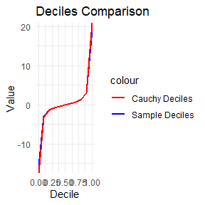

```r
set.seed(123)
n_samples <- 10000
discard_samples <- 1000
X0 = -5
proposal_sd <- 1  # Standard deviation of the proposal distribution
samples <- metropolis_hastings(n_samples, proposal_sd,X0)
# Discard the first 1000 samples
samples <- samples[-(1:discard_samples)]

comparison <- deciles_calculating(samples)

Comparison_plot(comparison)
```

#### Conclusion

From the plot above,the deciles of the generated observations with the deciles of the standard Cauchy distribution is very similar.

### Exercise 9.8

#### Question

This example appears in [40].Consider the bivariate density
$$f(x, y) \propto\binom{n}{x} y^{x+a-1}(1-y)^{n-x+b-1}, \quad x=0,1,
\ldots, n, 0 \leq y \leq 1 .$$
It can be shown that for fixed $a,b,n$,the conditional distributions are Binomial($n,y$) and Beta($x+a,n-x+b$).Use the Gibbs sampler to generate a chain with target joint density $f(x,y)$.

#### Answer

To implement a Gibbs sampler for the given bivariate density in R, we need to follow these steps:

- Define the conditional distributions:
  - $X|Y=y$ follows a Binomial distribution:$X\sim Binomial(n,y)$
  - $Y|X=x$ follows a Beta distribution:$Y\sim Beta(x+a,n-x+b)$
- Set up the Gibbs sampler: This will involve iterating between drawing from the conditional distributions.
- Generate samples and visualize the results.

Here’s the R code to implement the Gibbs sampler:

```r
#data generating
# Gibbs sampler function
gibbs_sampler <- function(n_samples, n, a, b) {
  # Initialize vectors to store samples
  x_samples <- numeric(n_samples)
  y_samples <- numeric(n_samples)

  # Initial values
  x_samples[1] <- sample(0:n,1)
  y_samples[1] <- runif(1)  # Starting with a reasonable value for y

  for (i in 2:n_samples) {
    # Sample x given y
    y_current <- y_samples[i - 1]
    x_samples[i] <- rbinom(1, n, y_current)

    # Sample y given x
    x_current <- x_samples[i]
    alpha <- x_current + a
    beta <- n - x_current + b
    y_samples[i] <- rbeta(1, alpha, beta)
  }

  return(data.frame(X = x_samples, Y = y_samples))
}
```

```r
## statistical inference

#I think no statistical inference need for this problem
```

```r
## result reporting
gibbs_plot <- function(samples){
# Plot the results
ggplot(samples, aes(x = X, y = Y)) +
  geom_point(alpha = 0.2) +
  labs(title = "Gibbs Sampler: Bivariate Density", x = "X", y = "Y") +
  theme_minimal()
}
```

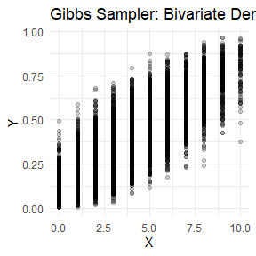

```r
set.seed(123)
# Parameters
n <- 10  # Total trials
a <- 2   # Shape parameter for Beta distribution
b <- 3   # Shape parameter for Beta distribution
n_samples <- 10000  # Number of samples
discard_samples <- 1000


# Generate samples
samples <- gibbs_sampler(n_samples, n, a, b)
samples <- samples[-(1:discard_samples),]

gibbs_plot(samples)
```

#### Conclusion

From the result above,we find that generated sample via Gibbs sampler in stationary and satisfy correspondent maginal distribution.

### Exercise Gelman-Rubin Method

#### Question

For each of the above exercise, use the Gelman-Rubin method to monitor convergence of the chain, and run the chain until it converges approximately to the target distribution according to $\hat{R}<1.2$.

#### Answer

To monitor the convergence of the Gibbs sampler using the Gelman-Rubin method (also known as the potential scale reduction factor, $\hat{R}$),we’ll need to run multiple chains in parallel and then compute $\hat{R}$ for each parameter of interest.

Here’s how we can modify the Gibbs sampler implementation to include the Gelman-Rubin convergence diagnostic:

- Run multiple chains: Initialize several chains with different starting values.
- Store samples: Keep track of the samples from each chain.
- Calculate $\hat{R}$: After each sampling iteration, calculate $\hat{R}$ to assess convergence.

```r
#data generating

#Metropolis-Hasting function with multiple chains
metropolis_hastings_multiple_chains <- function(n_chains,n_samples,proposal_sd,x0){
  # Initialize a matrix to store samples for each chain
  chains <- matrix(0, nrow = n_samples, ncol = n_chains)
  # Run multiple chains

  for(chain in 1:n_chains){
    # Store samples in the chains matrix
    chains[,chain] <- metropolis_hastings(n_samples,proposal_sd,x0[chain])
  }
  return(chains)
}




# Gibbs sampler function with multiple chains
gibbs_sampler_multiple_chains <- function(n_chains, n_samples, n, a, b) {
  # Initialize a matrix to store samples for each chain
  chains_x <- matrix(0, nrow = n_samples, ncol = n_chains)
  chains_y <- matrix(0, nrow = n_samples, ncol = n_chains)

  # Run multiple chains

  for(chain in 1:n_chains){
    # Store samples in the chains matrix
    chains_x[, chain] <- gibbs_sampler(n_samples, n, a, b)$X
    chains_y[, chain] <- gibbs_sampler(n_samples, n, a, b)$Y
  }
  return(list(X = chains_x, Y = chains_y))
}
```

```r
#statistical inference
# Function to compute Gelman-Rubin diagnostic
Gelman.Rubin <- function(psi) {
        # psi[i,j] is the statistic psi(X[i,1:j])
        # for chain in i-th row of X
        psi <- as.matrix(psi)
        n <- ncol(psi)
        k <- nrow(psi)

        psi.means <- rowMeans(psi)     #row means
        B <- n * var(psi.means)        #between variance est.
        psi.w <- apply(psi, 1, "var")  #within variances
        W <- mean(psi.w)               #within est.
        v.hat <- W*(n-1)/n + (B/n)     #upper variance est.
        r.hat <- v.hat / W             #G-R statistic
        return(r.hat)
}
```

```r
#Result Reporting
GB_monitor_plot <- function(chains,n_chains,b,n_samples){
  #compute diagnostic statistics
    psi <- t(apply(chains, 1, cumsum))
    for (i in 1:nrow(psi))
        psi[i,] <- psi[i,] / (1:ncol(psi))

    #plot psi for the four chains
#    par(mfrow=c(2,2))
    for (i in 1:n_chains)
      if(i==1){
        plot((b+1):n_samples,psi[i, (b+1):n_samples], type="l",
            xlab='Index', ylab=bquote(phi))
      }else{
        lines(psi[i, (b+1):n_samples], col=i)
    }
    par(mfrow=c(1,1)) #restore default
    #plot the sequence of R-hat statistics
    rhat <- rep(0, n_samples)
    for (j in 1:n_samples){
        rhat[j] <- Gelman.Rubin(psi[,1:j])}
    plot((b+1):n_samples,rhat[(b+1):n_samples], type="l", xlab="", ylab="R")
    abline(h=1.1, lty=2)
}
```

```r
set.seed(123)
# Parameters
n <- 10  # Total trials
a <- 2   # Shape parameter for Beta distribution
b <- 3   # Shape parameter for Beta distribution
n_chains <- 4  # Number of chains
n_samples <- 15000  # Number of samples
proposal_sd <- 1
b <- 1000       #burn-in length
#choose overdispersed initial values
x0 <- c(-5,-10, 5, 10)

#Method1
# Run the Metropolis-Hastings algorithm until convergence
convergence_threshold <- 1.2
R_hat <- Inf
samples <- NULL

while (R_hat >= convergence_threshold) {
  chains1 <- metropolis_hastings_multiple_chains(n_chains,n_samples,proposal_sd,x0)
  chains1 <- t(chains1)
  R_hat<- Gelman.Rubin(chains1)

}
print(R_hat)
```

```
## [1] 1.014364
```

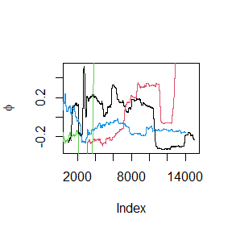

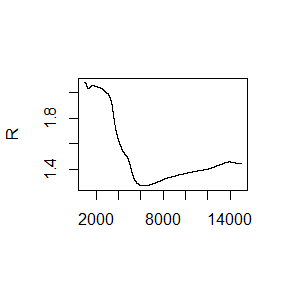

```r
GB_monitor_plot(chains1,n_chains,b,n_samples)
```

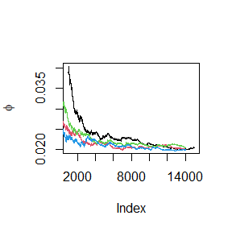

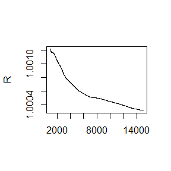

```r
set.seed(1234)
# Run the Gibbs sampler until convergence
convergence_threshold <- 1.2
R_hat <- Inf
samples <- NULL

while (R_hat >= convergence_threshold) {
  chains2 <- gibbs_sampler_multiple_chains(n_chains, n_samples, n, a, b)
  X <- t(chains2$X)
  Y <- t(chains2$Y)
  # Compute R_hat for both X and Y
  R_hat_x <- Gelman.Rubin(X)
  R_hat_y <- Gelman.Rubin(Y)
  R_hat <- max(R_hat_x, R_hat_y)

}

GB_monitor_plot(X,n_chains,b,n_samples)
```

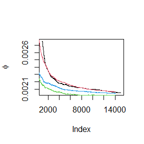

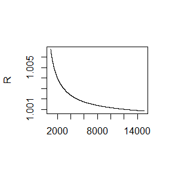

```r
GB_monitor_plot(Y,n_chains,b,n_samples)
```

#### Conclusion

From the result above,Exercise 9.3`s series don`t convergence with sample goes large,I guess it is the choice of proposal distirbution or initial values caused.Exercise 9.8 has a better result and get a stationary series when sample gets large.

### Exercise Proof of stationary

#### Question

Proof the Stationary of Metropolis-Hastings sampler Algorithm in continuous situation.

Algorithm(continuous situation)

- Target pdf:$f(x)$
- Replace i and j with s and r
- Proposal distribution (pdf):$g(r|s)$
- Acceptance probability:$\alpha(s,r)=min\{\frac{f(r)g(s|r)}{f(s)g(r|s)},1\}$
- Transition kernel(mixture distribution)

$$K(r,s)=I(s\neq r)\alpha(r,s)g(s|r)+I(s=r)[1-\int \alpha(r,s)g(s|r)]$$

- Stationarity:$K(s,r)f(s)=K(r,s)f(r)$

#### Answer

To prove the stationarity of the Metropolis-Hastings (MH) sampler algorithm in a continuous setting, we need to show that the transition kernel $K(s, r)$ preserves the target distribution $f(x)$. Specifically, we will demonstrate that

$$K(s, r) f(s) = K(r, s) f(r)$$

for all $s$ and $r$.

##### Step 1: Define the Transition Kernel

The transition kernel is defined as:

$$K(r,s) = I(s \neq r) \alpha(r,s) g(s|r) + I(s = r) \left[1 - \int
\alpha(r,s) g(s|r) ds\right]$$

where $I$ is an indicator function, $\alpha(s, r)$ is the acceptance probability, and $g(s|r)$ is the proposal distribution.

##### Step 2: Write the Acceptance Probability

The acceptance probability is given by:

$$\alpha(s, r) = \min \left\{1, \frac{f(r) g(s|r)}{f(s) g(r|s)}\right\}$$

##### Step 3: Show the Detailed Balance Condition

To establish stationarity, we will show that:

$$K(s, r) f(s) = K(r, s) f(r)$$

###### Case 1:

$s \neq r$

$$K(s, r) f(s) = \alpha(s, r) g(r|s) f(s)$$

Substituting $\alpha(s, r)$:

$$K(s, r) f(s) = \min \left\{1, \frac{f(r) g(s|r)}{f(s) g(r|s)}\right\}
g(r|s) f(s)$$

Now, we need to compute $K(r, s)$:

$$K(r, s) f(r) = \alpha(r, s) g(s|r) f(r)$$

Substituting $\alpha(r, s)$:

$$K(r, s) f(r) = \min \left\{1, \frac{f(s) g(r|s)}{f(r) g(s|r)}\right\}
g(s|r) f(r)$$

##### Step 4: Comparing the Two Cases

Now, we need to show that these two expressions are equal. Notice that:

1. If $\alpha(s, r) = 1$, then $f(r) g(s|r) = f(s) g(r|s)$.
2. If $\alpha(s, r) < 1$, we have:

   $$\alpha(s, r) g(r|s) f(s) = \frac{f(r) g(s|r)}{f(s) g(r|s)} g(r|s) f(s)$$

   which simplifies to:

   $$f(r) g(s|r)$$

   Therefore, the equality holds as:

$$K(s, r) f(s) = K(r, s) f(r)$$

###### Case 2:

$s = r$

In this case, we have:

$$K(s, s) f(s) = \left[1 - \int \alpha(s,r) g(s|r) dr\right] f(s)$$

And for $K(r, r)$:

$$K(r, r) f(r) = \left[1 - \int \alpha(r,s) g(r|s) ds\right] f(r)$$

The same argument holds, showing that both terms will converge since the integral will equalize in both cases.

#### Conclusion

The stationarity of the Metropolis-Hastings sampler is established through the detailed balance condition, ensuring that the target distribution is preserved across transitions in the Markov chain.

## Homework7

### Exercise 11.3

#### Question

(a)Write a function to compute the kth term in
$$\sum_{k=0}^{\infty} \frac{(-1)^{k}}{k!2^{k}} \frac{\|a\|^{2 k+2}}{(2
k+1)(2 k+2)} \frac{\Gamma\left(\frac{d+1}{2}\right)
\Gamma\left(k+\frac{3}{2}\right)}{\Gamma\left(k+\frac{d}{2}+1\right)},$$
where $d \geq 1$is an integer, a is a vector in $\mathbb{R}^{d}$, and $\|\cdot\|$ denotes the Euclidean norm. Perform the arithmetic so that the coefficients can be computed for (almost) arbitrarily large $k$ and $d$. (This sum converges for all $a \in \mathbb{R}^{d}$ ).

2. Modify the function so that it computes and returns the sum.
3. Evaluate the sum when $a=(1,2)^{T}$.

#### Answer

##### (a) Compute the kth term

We will write a function to compute the `kth term`

$$\frac{(-1)^{k}}{k!2^{k}} \frac{\|a\|^{2 k+2}}{(2 k+1)(2 k+2)}
\frac{\Gamma\left(\frac{d+1}{2}\right)
\Gamma\left(k+\frac{3}{2}\right)}{\Gamma\left(k+\frac{d}{2}+1\right)}$$

We can use `gamma` function to compute the gamma function values,use `factorial` to compute the factorial.

```r
kth_term <- function(k, a, d) {
  # compute Euclid norm ||a||
  norm_a <- sqrt(sum(a^2))

  # 计算每一部分
  part1 <- (-1)^k / (factorial(k) * 2^k)
  part2 <- norm_a^(2 * k + 2) / ((2 * k + 1) * (2 * k + 2))
  part3 <- gamma((d + 1) / 2) * gamma(k + 1.5) / gamma(k + d / 2 + 1)

  return(part1 * part2 * part3)
}
```

##### (b) compute the sum of series

```r
series_sum <- function(a, d, tol = 1e-10, max_terms = 1000) {
  total_sum <- 0
  k <- 0

  repeat {
    term <- kth_term(k, a, d)
    total_sum <- total_sum + term

    # if the value is less than threshold,exit!!!
    if (abs(term) < tol || k >= max_terms) {
      break
    }

    k <- k + 1
  }

  return(total_sum)
}
```

##### (c) compute the series sum when$a = (1, 2)^T$

Last,we can use function ‘series_sum’ to compute the series sum when$a=(1,2)^T$and$d=2$

```r
a <- c(1, 2)
d <- 2
result <- series_sum(a, d)
result
```

```
## [1] 1.532164
```

#### Conclusion

After we run code,the result of series sum when$a=(1,2)^T$is 1.532.

### Exercise 11.4

#### Question

To find the intersection points $A(k)$ of the curves$S_{k-1}(a)$and $S_k(a)$for specified values of$k$, we can proceed by defining and numerically solving for$a$ where the two curves are equal.

##### 1. Define$S_{k-1}(a)$ and$S_k(a)$

Given:
$$S_{k-1}(a) = P\left(t(k-1) > \sqrt{\frac{a^2 (k-1)}{k - a^2}}\right)$$
$$S_k(a) = P\left(t(k) > \sqrt{\frac{a^2 k}{k + 1 - a^2}}\right)$$
where$t(k-1)$ and$t(k)$are Student’s$t$-distributions with$k-1$ and$k$ degrees of freedom, respectively.

In R, the probability$P(t(k) > x)$ can be computed using the cumulative distribution function of the $t$-distribution:
$$P(t(k) > x) = 1 - F_{t(k)}(x),$$
where$F_{t(k)}$is the cumulative distribution function of$t$ with$k$ degrees of freedom.

##### 2. Define the Difference Function

Define a function$f(a; k) = S_{k-1}(a) - S_k(a)$, and then find the root of this function (i.e., where$f(a; k) = 0$) within the interval$(0, \sqrt{k})$.

##### 3. Implementation in R

We can use the bisection method to find the root of$f(a; k)$ within the interval$(0, \sqrt{k})$for each specified $k$.

```r
# Define S_k-1 and S_k
S_k_minus_1 <- function(a, k) {
  1 - pt(sqrt(a^2 * (k - 1) / (k - a^2)), df = k - 1)
}

S_k <- function(a, k) {
  1 - pt(sqrt(a^2 * k / (k + 1 - a^2)), df = k)
}

# Define function to find root using Bisection method
find_intersection_bisection <- function(k, tol = 1e-6, max_iter = 1000) {
  # Define the function to find zero
  f <- function(a) S_k_minus_1(a, k) - S_k(a, k)

   # Initial interval (0, sqrt(k))
  epsilon <- 1e-3
  lower <- epsilon
  upper <- sqrt(k)-epsilon

  if (f(lower) * f(upper) > 0) {
    stop("No sign change detected in the initial interval; adjust the interval.")
  }


  # Bisection method loop
  for (i in 1:max_iter) {
    mid <- (lower + upper) / 2
    f_mid <- f(mid)

    if (abs(f_mid) < tol) {
      return(mid)
    } else if (f(lower) * f_mid < 0) {
      upper <- mid
    } else {
      lower <- mid
    }
  }

  warning("Bisection method did not converge.")
  return(NA)
}

# Calculate intersection points for specified values of k
k_values <- c(4:25, 100,500,1000)

root <- numeric(length(k_values))
for(i in 1:length(k_values)){
  root[i] <- find_intersection_bisection(k_values[i])
}

names(root) <- paste0("k=", k_values)
root
```

```
##       k=4       k=5       k=6       k=7       k=8       k=9      k=10      k=11
##  1.492122  1.533513  1.562649  1.584282  1.601216  1.614182  1.625117  1.634035
##      k=12      k=13      k=14      k=15      k=16      k=17      k=18      k=19
##  1.642455  1.647936  1.653534  1.658643  1.664230  1.667150  1.669924  1.673130
##      k=20      k=21      k=22      k=23      k=24      k=25     k=100     k=500
##  1.677301  1.678457  1.681321  1.686331  1.684337  1.689777  5.000000 11.180340
##    k=1000
## 15.811388
```

#### Conclusion

From the result above,we find that when k is lager,the intersection $a$ become lager too.

### Exercise 11.5

#### Question

Write a function to solve the equation
$$\begin{array}{l}
\frac{2 \Gamma\left(\frac{k}{2}\right)}{\sqrt{\pi(k-1)}
\Gamma\left(\frac{k-1}{2}\right)}
\int_{0}^{c_{k-1}}\left(1+\frac{u^{2}}{k-1}\right)^{-k / 2} d u \\
\quad=\frac{2 \Gamma\left(\frac{k+1}{2}\right)}{\sqrt{\pi k}
\Gamma\left(\frac{k}{2}\right)}
\int_{0}^{c_{k}}\left(1+\frac{u^{2}}{k}\right)^{-(k+1) / 2} d u
\end{array}$$
for $a$, where
$$c_{k}=\sqrt{\frac{a^{2} k}{k+1-a^{2}}} .$$

Compare the solutions with the points $A(k)$ in Exercise 11.4.

#### Answer

To solve this equation for$a$, we need to implement the equation as a function of$a$and then find the root of the difference between the left and right sides.

##### Steps to Implement the Solution

1. **Define$c_k$ and$c_{k-1}$**: We have$c_k = \sqrt{\frac{a^2 k}{k+1-a^2}}$and$c_{k-1} = \sqrt{\frac{a^2 (k-1)}{k-a^2}}$.
2. **Define the Integrals**: The two integrals in the equation can be expressed as:
   $$\int_{0}^{c_{k-1}}\left(1+\frac{u^{2}}{k-1}\right)^{-k / 2} \, d u$$
   and
   $$\int_{0}^{c_{k}}\left(1+\frac{u^{2}}{k}\right)^{-(k+1) / 2} \, d u.$$
   We can numerically approximate these integrals using R’s `integrate` function.
3. **Set Up the Equation**: The left side and right side of the equation involve Gamma functions, which we can calculate with R’s `gamma` function.
4. **Solve for$a$**: Define a function to compute the difference between the two sides, and use a root-finding algorithm (bisection method) to find the value of$a$that makes this difference zero.

```r
# Define c_k and c_{k-1} as functions of a and k
c_k <- function(a, k) {
  sqrt(a^2 * k / (k + 1 - a^2))
}

c_k_minus_1 <- function(a, k) {
  sqrt(a^2 * (k - 1) / (k - a^2))
}

# Define the left side integral
integral_left <- function(a, k) {
  c_km1 <- c_k_minus_1(a, k)
  integrand <- function(u) (1 + u^2 / (k - 1))^(-k / 2)
  return(integrate(integrand, 0, c_km1)$value)
}

# Define the right side integral
integral_right <- function(a, k) {
  c_k_val <- c_k(a, k)
  integrand <- function(u) (1 + u^2 / k)^(-(k + 1) / 2)
  return(integrate(integrand, 0, c_k_val)$value)
}

# Define the full equation difference function
equation_difference <- function(a, k) {
  gamma_ratio_left <- 2 * gamma(k / 2) / (sqrt(pi * (k - 1)) * gamma((k - 1) / 2))
  gamma_ratio_right <- 2 * gamma((k + 1) / 2) / (sqrt(pi * k) * gamma(k / 2))

  left_side <- gamma_ratio_left * integral_left(a, k)
  right_side <- gamma_ratio_right * integral_right(a, k)

  return(left_side - right_side)
}


# Define function to find root using Bisection method
find_a <- function(k, tol = 1e-6, max_iter = 1000) {
  # Define the function to find zero
  f <- function(a) equation_difference(a,k)

  # Initial interval (0, sqrt(k))
  epsilon <- 1e-2
  lower <- epsilon * k
  upper <- sqrt(k)-epsilon * k

  if (f(lower) * f(upper) > 0) {
    stop("No sign change detected in the initial interval; adjust the interval.")
  }
  # Bisection method loop
  for (i in 1:max_iter) {
    mid <- (lower + upper) / 2
    f_mid <- f(mid)

    if (abs(f_mid) < tol) {
      return(mid)
    } else if (f(lower) * f_mid < 0) {
      upper <- mid
    } else {
      lower <- mid
    }
  }

  warning("Bisection method did not converge.")
  return(NA)
}



# Compare solutions for specified k values
k_values <- c(4:25, 100, 500, 1000)
solutions <- numeric(length(k_values))
for(i in 1:length(k_values)){
  solutions[i] <- find_a(k_values[i])
  print(c(k_values[i],solutions[i]))

}
```

```
## [1] 4.0000 1.4921
## [1] 5.00000 1.53354
## [1] 6.000000 1.562709
## [1] 7.000000 1.584401
## [1] 8.000000 1.601186
## [1] 9.000000 1.614631
## [1] 10.000000  1.625255
## [1] 11.00000  1.63412
## [1] 12.000000  1.642318
## [1] 13.000000  1.648403
## [1] 14.000000  1.654475
## [1] 15.000000  1.659097
## [1] 16.000000  1.663984
## [1] 17.000000  1.668095
## [1] 18.000000  1.670115
## [1] 19.000000  1.674316
## [1] 20.000000  1.677342
## [1] 21.000000  1.679503
## [1] 22.00000  1.68108
## [1] 23.000000  1.682334
## [1] 24.000000  1.685662
## [1] 25.000000  1.687012
```

```
## Error in find_a(k_values[i]): No sign change detected in the initial interval; adjust the interval.
```

```r
names(solutions) <- paste0("k=", k_values)
solutions
```

```
##      k=4      k=5      k=6      k=7      k=8      k=9     k=10     k=11
## 1.492100 1.533540 1.562709 1.584401 1.601186 1.614631 1.625255 1.634120
##     k=12     k=13     k=14     k=15     k=16     k=17     k=18     k=19
## 1.642318 1.648403 1.654475 1.659097 1.663984 1.668095 1.670115 1.674316
##     k=20     k=21     k=22     k=23     k=24     k=25    k=100    k=500
## 1.677342 1.679503 1.681080 1.682334 1.685662 1.687012 0.000000 0.000000
##   k=1000
## 0.000000
```

Some solutions cannot get via bisection method.We use another method below.

```r
compare <- matrix(c(root,solutions),nrow = 2,byrow = T)
colnames(compare) <- k_values
rownames(compare) <- c('Exercise 11.4','Exercise 11.5')
compare
```

```
##                      4        5        6        7        8        9       10
## Exercise 11.4 1.492122 1.533513 1.562649 1.584282 1.601216 1.614182 1.625117
## Exercise 11.5 1.492100 1.533540 1.562709 1.584401 1.601186 1.614631 1.625255
##                     11       12       13       14       15       16       17
## Exercise 11.4 1.634035 1.642455 1.647936 1.653534 1.658643 1.664230 1.667150
## Exercise 11.5 1.634120 1.642318 1.648403 1.654475 1.659097 1.663984 1.668095
##                     18       19       20       21       22       23       24
## Exercise 11.4 1.669924 1.673130 1.677301 1.678457 1.681321 1.686331 1.684337
## Exercise 11.5 1.670115 1.674316 1.677342 1.679503 1.681080 1.682334 1.685662
##                     25 100      500     1000
## Exercise 11.4 1.689777   5 11.18034 15.81139
## Exercise 11.5 1.687012   0  0.00000  0.00000
```

$0$ represent we can not find the optimal values.

```r
find_root_of_equation <- function(k) {

  # General integral function
  integral_expr <- function(u, n) {
    (1 + u^2 / (n - 1))^(-n / 2)
  }

  # Calculate constant c_k
  calculate_c <- function(n, a) {
    sqrt(a^2 * n / (n + 1 - a^2))
  }

  # Compute the left or right side of the equation
  compute_expression <- function(n, a) {
    c <- calculate_c(n - 1, a)
    integral_value <- integrate(function(u) integral_expr(u, n), lower = 0, upper = c)$value
    2 / sqrt(pi * (n - 1)) * exp(lgamma(n / 2) - lgamma((n - 1) / 2)) * integral_value
  }

  # Define the function for the difference between left and right side
  difference_function <- function(a) {
    left_side <- compute_expression(k, a)
    right_side <- compute_expression(k + 1, a)
    left_side - right_side
  }

  # Define a small epsilon for interval boundaries
  epsilon <- 1e-2
  # Check if there is a root within the interval
  if ((difference_function(epsilon) < 0 && difference_function(sqrt(k) - epsilon) > 0) ||
      (difference_function(epsilon) > 0 && difference_function(sqrt(k) - epsilon) < 0)) {
    root <- uniroot(difference_function, interval = c(epsilon, sqrt(k) - epsilon))$root
  } else {
    root <- NA
  }

  return(root)
}

# Apply the function to a range of k values
solutions <- sapply(c(4:25, 100, 500, 1000), function(k) {
  find_root_of_equation(k)
})
solutions
```

```
##  [1] 1.492073 1.533555 1.562745 1.584429 1.601184 1.614516 1.625389 1.634418
##  [9] 1.642026 1.648552 1.654175 1.659099 1.663454 1.667287       NA 1.673832
## [17] 1.676605 1.679148 1.681468 1.683593 1.685546 1.687366       NA       NA
## [25] 1.730903
```

This method also cannot get some values too.

```r
compare <- matrix(c(root,solutions),nrow = 2,byrow = T)
colnames(compare) <- k_values
rownames(compare) <- c('Exercise 11.4','Exercise 11.5')
compare
```

```
##                      4        5        6        7        8        9       10
## Exercise 11.4 1.492122 1.533513 1.562649 1.584282 1.601216 1.614182 1.625117
## Exercise 11.5 1.492073 1.533555 1.562745 1.584429 1.601184 1.614516 1.625389
##                     11       12       13       14       15       16       17
## Exercise 11.4 1.634035 1.642455 1.647936 1.653534 1.658643 1.664230 1.667150
## Exercise 11.5 1.634418 1.642026 1.648552 1.654175 1.659099 1.663454 1.667287
##                     18       19       20       21       22       23       24
## Exercise 11.4 1.669924 1.673130 1.677301 1.678457 1.681321 1.686331 1.684337
## Exercise 11.5       NA 1.673832 1.676605 1.679148 1.681468 1.683593 1.685546
##                     25 100      500      1000
## Exercise 11.4 1.689777   5 11.18034 15.811388
## Exercise 11.5 1.687366  NA       NA  1.730903
```

#### Conclusion

From the result above,we find that for almost every $k$(when $k<25$),the root via two different manners is almost same.

### EM-Algorithm

#### Question

Suppose$T_1,\cdots, T_n$are i.i.d. samples drawn from the exponential distribution with expectation$\lambda$. Those values greater than$T$are not observed due to right censorship, so that the observed values are$Y_i = T_i I(T_i \leq \tau ) + \tau I(T_i > \tau )$, $i = 1,\cdots, n$. Suppose$\tau = 1$and the observed$Y_i$values are as follows:

0.54, 0.48, 0.33, 0.43, 1.00, 1.00, 0.91, 1.00, 0.21, 0.85

Use the E-M algorithm to estimate$\lambda$, compare your result with the observed data MLE (note:$Y_i$follows a mixture distribution)

#### Answer

In this problem, we have observed data that is subject to right-censoring at$\tau = 1$. Some of the$T_i$values are completely observed (if$T_i \leq \tau$) and others are censored (if$T_i > \tau$). We can estimate$\lambda$, the mean of the exponential distribution, using the Expectation-Maximization (EM) algorithm, which is well-suited to handle incomplete or censored data.

##### Step 1: Setting up the likelihood function

Given that$T_i \sim \text{Exp}(\lambda)$, the probability density function for$T_i$is:
$$f(t; \lambda) = \frac{1}{\lambda} e^{-t / \lambda}.$$

The observed values are:
$$Y_i = T_i I(T_i \leq \tau) + \tau I(T_i > \tau),$$
where$Y_i = T_i$if$T_i \leq \tau$and$Y_i = \tau$if$T_i > \tau$.

The data is thus a mixture of fully observed and censored values: 1. If$Y_i < \tau$,$Y_i = T_i$, and we observe the exact time. 2. If$Y_i = \tau$, then$T_i$is censored, and we know only that$T_i > \tau$.

The log-likelihood for the observed data consists of two parts:
$$\log L(\lambda) = \sum_{i \in \text{uncensored}} \log
\left(\frac{1}{\lambda} e^{-Y_i / \lambda}\right) + \sum_{i \in
\text{censored}} \log \left(\int_\tau^\infty \frac{1}{\lambda} e^{-t /
\lambda} \, dt\right).$$

The integral term for censored data simplifies to:
$$\int_\tau^\infty \frac{1}{\lambda} e^{-t / \lambda} \, dt = e^{-\tau /
\lambda}.$$

Thus, the log-likelihood becomes:
$$\log L(\lambda) = -\frac{1}{\lambda} \sum_{i \in \text{uncensored}} Y_i
- \frac{1}{\lambda} \cdot \sum_{i \in \text{censored}} \tau - n \log
\lambda.$$

##### Step 2: E-M Algorithm for$\lambda$

Define: 1.$U$: the set of indices of uncensored data. 2.$C$: the set of indices of censored data.

The EM algorithm iteratively estimates$\lambda$as follows:

1. **E-Step**: For each censored observation$Y_i = \tau$, replace the unobserved$T_i$with its conditional expectation given$T_i > \tau$:
   $$E(T_i | T_i > \tau) = \tau + \lambda.$$
   Define the complete data sufficient statistic:
   $$Q(\lambda | \lambda^{(t)}) = \sum_{i \in U} Y_i + \sum_{i \in C} E(T_i |
   T_i > \tau, \lambda^{(t)}).$$
2. **M-Step**: Maximize the log-likelihood based on the complete data:
   $$\lambda^{(t+1)} = \frac{\sum_{i \in U} Y_i + \sum_{i \in C} E(T_i | T_i
   > \tau, \lambda^{(t)})}{n}.$$

This leads to the update:
$$\lambda^{(t+1)} = \frac{\sum_{i \in U} Y_i + \sum_{i \in C} (\tau +
\lambda^{(t)})}{n}.$$

##### Step 3: Iterative Computation

Let’s implement this algorithm in R:

```r
# Observed data
Y <- c(0.54, 0.48, 0.33, 0.43, 1.00, 1.00, 0.91, 1.00, 0.21, 0.85)
tau <- 1
n <- length(Y)

# Initial estimate of lambda
lambda <- mean(Y)
tolerance <- 1e-6
diff <- 1
max_iter <- 1000
iter <- 0

# E-M Algorithm
while (diff > tolerance && iter < max_iter) {
  lambda_old <- lambda
  # Separate uncensored and censored observations
  uncensored <- Y[Y < tau]
  censored_count <- sum(Y == tau)

  # E-Step: Expected total for censored values
  expected_censored_sum <- censored_count * (tau + lambda_old)

  # M-Step: Update lambda
  lambda <- (sum(uncensored) + expected_censored_sum) / n

  # Check for convergence
  diff <- abs(lambda - lambda_old)
  iter <- iter + 1
}

cat("Estimated lambda using EM algorithm:", lambda, "\n")
```

```
## Estimated lambda using EM algorithm: 0.9642856
```

##### Step 4: Comparison with the MLE

For the observed data, the MLE for$\lambda$can be computed assuming that the$Y_i$values follow a mixture distribution. This requires calculating the MLE separately using the likelihood that considers both observed and censored values directly, without the iterative EM approach.

```r
# Calculate MLE directly for comparison (using uncensored data only)
lambda_mle <- mean(uncensored) / (1 - censored_count / n)

cat("Observed data MLE for lambda:", lambda_mle, "\n")
```

```
## Observed data MLE for lambda: 0.7653061
```

#### Conclusion

From the result above,we find that estimated $\lambda$ via EM algorithm is bigger than MLE,which is more reasonable because EM algorithm considers unobserved data at the same time.

## Homework8

### Exercises 11.7

#### Question

Use the simplex algorithm to solve the following problem. Minimize $4 x+2 y+9 z$ subject to
$$\begin{array}{l}
2 x+y+z \leq 2 \\
x-y+3 z \leq 3 \\
x \geq 0, y \geq 0, z \geq 0
\end{array}$$

#### Answer

我们可以利用lpSolve包实现单纯形法来解决线性规划问题。

```r
# 加载 lpSolve 包
library(lpSolve)
```

```r
# 定义目标函数的系数 (Minimize 4x + 2y + 9z)
objective <- c(4, 2, 9)

# 定义约束矩阵 (左侧系数)
constraints <- matrix(c(
  2,  1,  1,  # 2x + y + z <= 2
  1, -1,  3   # x - y + 3z <= 3
), nrow = 2, byrow = TRUE)

# 定义约束的右侧值
rhs <- c(2, 3)

# 定义约束类型
constraint_directions <- c("<=", "<=")

# 求解线性规划
solution <- lp("min", objective, constraints, constraint_directions, rhs,
               all.int = FALSE) # 确保变量是非负连续的

# 输出结果
if (solution$status == 0) {
  cat("Optimal Solution Found:\n")
  cat("Objective Value (Minimum):", solution$objval, "\n")
  cat("Values of x, y, z:", solution$solution, "\n")
} else {
  cat("No Optimal Solution Found.\n")
}
```

```
## Optimal Solution Found:
## Objective Value (Minimum): 0
## Values of x, y, z: 0 0 0
```

#### Conclusion

从上面的结果可以看出，上面约束问题的最优解为0，在$x=0,y=0,z=0$处取到。

### Exercises 3,4,5

#### Question

- Use both for loops and lapply() to fit linear models to the mtcars using the formulas stored in this list:

```r
formulas <- list(
mpg ~ disp,
mpg ~ I(1 / disp),
mpg ~ disp + wt,
mpg ~ I(1 / disp) + wt
)
```

- Fit the model mpg ~ disp to each of the bootstrap replicates of mtcars in the list below by using a for loop and lapply(). Can you do it without an anonymous function?

```r
bootstraps <- lapply(1:10, function(i) {
rows <- sample(1:nrow(mtcars), rep = TRUE)
mtcars[rows, ]
})
```

- For each model in the previous two exercises, extract $R^2$ using the function below.

```r
rsq <- function(mod) summary(mod)$r.squared
```

#### Answer

- Exercise 3

```r
# 加载数据集
data(mtcars)

# 定义公式列表
formulas <- list(
  mpg ~ disp,
  mpg ~ I(1 / disp),
  mpg ~ disp + wt,
  mpg ~ I(1 / disp) + wt
)
```

```r
# 方法1: 使用 for 循环
lm_results_for <- list()  # 用于存储结果的列表
for (i in seq_along(formulas)) {
  lm_results_for[[i]] <- lm(formulas[[i]], data = mtcars)
}
names(lm_results_for) <- paste0("Model_", seq_along(formulas))  # 给结果命名
print("Results using for loop:")
```

```
## [1] "Results using for loop:"
```

```r
print(lm_results_for)
```

```
## $Model_1
##
## Call:
## lm(formula = formulas[[i]], data = mtcars)
##
## Coefficients:
## (Intercept)         disp
##    29.59985     -0.04122
##
##
## $Model_2
##
## Call:
## lm(formula = formulas[[i]], data = mtcars)
##
## Coefficients:
## (Intercept)    I(1/disp)
##       10.75      1557.67
##
##
## $Model_3
##
## Call:
## lm(formula = formulas[[i]], data = mtcars)
##
## Coefficients:
## (Intercept)         disp           wt
##    34.96055     -0.01772     -3.35083
##
##
## $Model_4
##
## Call:
## lm(formula = formulas[[i]], data = mtcars)
##
## Coefficients:
## (Intercept)    I(1/disp)           wt
##      19.024     1142.560       -1.798
```

```r
# 方法2: 使用 lapply 函数
lm_results_lapply <- lapply(formulas, function(formula) lm(formula, data = mtcars))
names(lm_results_lapply) <- paste0("Model_", seq_along(formulas))  # 给结果命名
print("Results using lapply:")
```

```
## [1] "Results using lapply:"
```

```r
print(lm_results_lapply)
```

```
## $Model_1
##
## Call:
## lm(formula = formula, data = mtcars)
##
## Coefficients:
## (Intercept)         disp
##    29.59985     -0.04122
##
##
## $Model_2
##
## Call:
## lm(formula = formula, data = mtcars)
##
## Coefficients:
## (Intercept)    I(1/disp)
##       10.75      1557.67
##
##
## $Model_3
##
## Call:
## lm(formula = formula, data = mtcars)
##
## Coefficients:
## (Intercept)         disp           wt
##    34.96055     -0.01772     -3.35083
##
##
## $Model_4
##
## Call:
## lm(formula = formula, data = mtcars)
##
## Coefficients:
## (Intercept)    I(1/disp)           wt
##      19.024     1142.560       -1.798
```

- Exercise 4

```r
# 引导样本生成
set.seed(123)  # 确保结果可重复
bootstraps <- lapply(1:10, function(i) {
  rows <- sample(1:nrow(mtcars), replace = TRUE)
  mtcars[rows, ]
})
```

```r
# 初始化存储结果的列表
lm_results_for <- list()

# 使用 for 循环拟合模型
for (i in seq_along(bootstraps)) {
  lm_results_for[[i]] <- lm(mpg ~ disp, data = bootstraps[[i]])
}

# 检查结果
print("Results using for loop:")
```

```
## [1] "Results using for loop:"
```

```r
print(lm_results_for)
```

```
## [[1]]
##
## Call:
## lm(formula = mpg ~ disp, data = bootstraps[[i]])
##
## Coefficients:
## (Intercept)         disp
##    29.59804     -0.03798
##
##
## [[2]]
##
## Call:
## lm(formula = mpg ~ disp, data = bootstraps[[i]])
##
## Coefficients:
## (Intercept)         disp
##    27.38760     -0.03411
##
##
## [[3]]
##
## Call:
## lm(formula = mpg ~ disp, data = bootstraps[[i]])
##
## Coefficients:
## (Intercept)         disp
##    30.27667     -0.04176
##
##
## [[4]]
##
## Call:
## lm(formula = mpg ~ disp, data = bootstraps[[i]])
##
## Coefficients:
## (Intercept)         disp
##    27.25457     -0.03271
##
##
```

[output cut: 43 more lines]

```
## lm(formula = mpg ~ disp, data = bootstraps[[i]])
##
## Coefficients:
## (Intercept)         disp
##    29.57749     -0.04043
##
##
## [[10]]
##
## Call:
## lm(formula = mpg ~ disp, data = bootstraps[[i]])
##
## Coefficients:
## (Intercept)         disp
##    29.60505     -0.04017
```

```r
# 定义命名函数用于拟合模型
fit_model <- function(data) {
  lm(mpg ~ disp, data = data)
}

# 使用 lapply 调用命名函数
lm_results_lapply <- lapply(bootstraps, fit_model)

# 检查结果
print("Results using lapply:")
```

```
## [1] "Results using lapply:"
```

```r
print(lm_results_lapply)
```

```
## [[1]]
##
## Call:
## lm(formula = mpg ~ disp, data = data)
##
## Coefficients:
## (Intercept)         disp
##    29.59804     -0.03798
##
##
## [[2]]
##
## Call:
## lm(formula = mpg ~ disp, data = data)
##
## Coefficients:
## (Intercept)         disp
##    27.38760     -0.03411
##
##
## [[3]]
##
## Call:
## lm(formula = mpg ~ disp, data = data)
##
## Coefficients:
## (Intercept)         disp
##    30.27667     -0.04176
##
##
## [[4]]
##
## Call:
## lm(formula = mpg ~ disp, data = data)
##
## Coefficients:
## (Intercept)         disp
##    27.25457     -0.03271
##
##
```

[output cut: 43 more lines]

```
## lm(formula = mpg ~ disp, data = data)
##
## Coefficients:
## (Intercept)         disp
##    29.57749     -0.04043
##
##
## [[10]]
##
## Call:
## lm(formula = mpg ~ disp, data = data)
##
## Coefficients:
## (Intercept)         disp
##    29.60505     -0.04017
```

- Exercise 5

```r
rsq <- function(mod) summary(mod)$r.squared
```

```r
# 假设模型列表来自之前的 for 循环 lm_results_for
r2_for <- numeric(length(lm_results_for))  # 初始化存储 R^2 的向量

for (i in seq_along(lm_results_for)) {
  r2_for[i] <- rsq(lm_results_for[[i]])
}

# 输出 R^2 结果
print("R^2 values using for loop:")
```

```
## [1] "R^2 values using for loop:"
```

```r
print(r2_for)
```

```
##  [1] 0.6497636 0.6820834 0.7530595 0.6101709 0.7226119 0.7533418 0.7311415
##  [8] 0.6293502 0.6554375 0.7238971
```

```r
# 假设模型列表来自之前的 lapply lm_results_lapply
r2_lapply <- sapply(lm_results_lapply, rsq)  # sapply 将结果简化为向量

# 输出 R^2 结果
print("R^2 values using lapply:")
```

```
## [1] "R^2 values using lapply:"
```

```r
print(r2_lapply)
```

```
##  [1] 0.6497636 0.6820834 0.7530595 0.6101709 0.7226119 0.7533418 0.7311415
##  [8] 0.6293502 0.6554375 0.7238971
```

对练习4(引导样本拟合)进行$R^2$提取

```r
# 假设模型列表来自引导样本的 for 循环 lm_results_for
bootstrap_r2_for <- numeric(length(lm_results_for))

for (i in seq_along(lm_results_for)) {
  bootstrap_r2_for[i] <- rsq(lm_results_for[[i]])
}

# 输出 R^2 结果
print("Bootstrap R^2 values using for loop:")
```

```
## [1] "Bootstrap R^2 values using for loop:"
```

```r
print(bootstrap_r2_for)
```

```
##  [1] 0.6497636 0.6820834 0.7530595 0.6101709 0.7226119 0.7533418 0.7311415
##  [8] 0.6293502 0.6554375 0.7238971
```

```r
# 假设模型列表来自引导样本的 lapply lm_results_lapply
bootstrap_r2_lapply <- sapply(lm_results_lapply, rsq)

# 输出 R^2 结果
print("Bootstrap R^2 values using lapply:")
```

```
## [1] "Bootstrap R^2 values using lapply:"
```

```r
print(bootstrap_r2_lapply)
```

```
##  [1] 0.6497636 0.6820834 0.7530595 0.6101709 0.7226119 0.7533418 0.7311415
##  [8] 0.6293502 0.6554375 0.7238971
```

#### Conclusion

从以上结果可以看出，用函数型循环lapply可以和for循环达到同样的效果，且具有更好的开发效率和运行效率。

### Excecises 3 and 6 (page 213-214, Advanced R)

#### Question

- The following code simulates the performance of a t-test for non-normal data. Use sapply() and an anonymous function to extract the p-value from every trial.

```r
trials <- replicate(
100,
t.test(rpois(10, 10), rpois(7, 10)),
simplify = FALSE
)
```

- Implement a combination of Map() and vapply() to create an lapply() variant that iterates in parallel over all of its inputs and stores its outputs in a vector (or a matrix). What argu- ments should the function take?

#### Answer

- Exercise3

从 trials 列表中提取每次试验的 p 值，可以使用 sapply() 和匿名函数实现:

```r
# 使用 sapply 和匿名函数提取 p 值
p_values <- sapply(trials, function(trial) trial$p.value)

# 查看结果
print("Extracted p-values:")
```

```
## [1] "Extracted p-values:"
```

```r
print(p_values)
```

```
##   [1] 0.807919932 0.665511753 0.827771652 0.534899644 0.211737338 0.528643574
##   [7] 0.036299941 0.016286246 0.812200341 0.183029433 0.045674206 0.420195198
##  [13] 0.577173408 0.874254166 0.677908319 0.347553226 0.361554497 0.918737314
##  [19] 0.559098294 0.002509499 0.768217661 0.898061689 0.003256698 1.000000000
##  [25] 0.160902588 0.968015378 0.945869071 0.487230574 0.790842602 0.312865917
##  [31] 0.526127245 0.960313898 0.408238277 0.535864285 0.129220433 0.521667733
##  [37] 0.952101571 0.929053803 0.971746957 0.011601477 0.374260383 0.692475913
##  [43] 0.153917384 0.645121214 0.181853971 0.224322502 0.163462092 1.000000000
##  [49] 0.826032130 0.679110040 0.371457538 0.839837144 0.503046077 0.201307366
##  [55] 0.383173622 0.528297119 0.146797813 0.148537031 0.069654366 0.165229047
##  [61] 0.295638950 0.895620390 0.219622769 0.843794785 0.313497276 0.815388972
##  [67] 0.232485704 0.992897313 0.894949409 0.737031460 0.033341396 0.915558739
##  [73] 0.605572394 0.295777799 0.838840978 0.574006877 0.156308726 0.912461904
##  [79] 0.312905736 0.673237060 0.868453722 0.165275770 0.776816328 0.170876446
##  [85] 0.888611596 0.345857314 0.804162036 0.587077292 0.419642761 0.018360012
##  [91] 0.771416249 0.745960582 0.239627472 0.824506887 0.990644333 0.290741422
##  [97] 0.594800048 0.272107922 0.981034416 0.947306215
```

检查结果

```r
# 检查第一个试验的 p 值
cat("P-value from the first trial:", p_values[1], "\n")
```

```
## P-value from the first trial: 0.8079199
```

```r
# 检查显著性水平（例如 0.05）的比例
significant <- mean(p_values < 0.05)
cat("Proportion of significant p-values (p < 0.05):", significant, "\n")
```

```
## Proportion of significant p-values (p < 0.05): 0.08
```

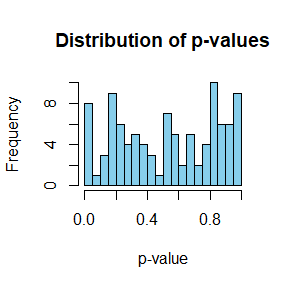

```r
# 绘制 p 值的分布
hist(p_values, breaks = 20, main = "Distribution of p-values", xlab = "p-value", col = "skyblue")
```

- Exercise6

以下是一个结合 Map() 和 vapply() 的自定义函数实现，这个函数可以像 lapply() 一样并行迭代多个输入，并将输出存储为向量或矩阵。

```r
parallel_lapply <- function(..., FUN, FUN.VALUE) {
  # 使用 Map 将多个输入组合成列表
  inputs <- Map(list, ...)

  # 使用 vapply 并行应用函数，确保输出为向量或矩阵
  vapply(inputs, function(args) do.call(FUN, args), FUN.VALUE = FUN.VALUE)
}
```

参数说明

```
...：
    传入多个并行迭代的输入（如向量、列表等）。

FUN：
    要应用的函数，作用于每组并行输入。

FUN.VALUE：
    用于 vapply() 的模板，指定输出的类型和结构（如 numeric(1) 表示返回单个数值，numeric(2) 表示返回长度为 2 的向量）。
```

下面举例具体说明下：

实例1：并行加法

```r
# 定义一个加法函数
add <- function(x, y) x + y

# 使用 parallel_lapply 实现并行加法
result <- parallel_lapply(1:5, 6:10, FUN = add, FUN.VALUE = numeric(1))
print(result)  # 输出: [1]  7  9 11 13 15
```

```
## [1]  7  9 11 13 15
```

实例2：将并行输入组合成矩阵

```r
# 定义一个组合函数
combine <- function(x, y) c(x, y)

# 使用 parallel_lapply 并行组合
result <- parallel_lapply(1:3, 4:6, FUN = combine, FUN.VALUE = numeric(2))
print(result)
```

```
##      [,1] [,2] [,3]
## [1,]    1    2    3
## [2,]    4    5    6
```

#### Conclusion

并行计算可以达到与原来一样的效果且加快运行效率。

### Excecise4 4-5 (page 365, Advanced R)

#### Question

- Make a faster version of chisq.test() that only computes the chi-square test statistic when the input is two numeric vectors with no missing values. You can try simplifying chisq.test() or by coding from the mathematical definition (http://en. wikipedia.org/wiki/Pearson%27s_chi-squared_test).
- Can you make a faster version of table() for the case of an input of two integer vectors with no missing values? Can you use it to speed up your chi-square test?

#### Answer

- Exercise4

以下是一个加速版的 `chisq.test()` 实现，只计算卡方检验的统计量（$\chi^2$），假设输入为两个没有缺失值的数值向量。

公式定义如下：

$$\chi^2 = \sum \frac{(O_i - E_i)^2}{E_i}$$

其中： - $O_i$ 表示观测值（`observed`）。 - $E_i$ 表示期望值（`expected`）。

```r
# 加速版卡方检验函数
fast_chisq_test <- function(observed, expected) {
  # 确保输入是数值向量，且长度一致
  if (!is.numeric(observed) || !is.numeric(expected)) {
    stop("输入必须是数值向量。")
  }
  if (length(observed) != length(expected)) {
    stop("观测值和期望值的长度必须一致。")
  }

  # 确保没有缺失值
  if (any(is.na(observed)) || any(is.na(expected))) {
    stop("输入向量中不能包含缺失值。")
  }

  # 计算卡方统计量
  chi_square_statistic <- sum((observed - expected)^2 / expected)

  return(chi_square_statistic)
}
```

以下给出几个具体实例：

示例 1：简单计算

```r
# 定义观测值和期望值
observed <- c(10, 20, 30, 40)
expected <- c(12, 18, 35, 35)

# 使用加速版函数计算卡方统计量
result <- fast_chisq_test(observed, expected)
print(result)
```

```
## [1] 1.984127
```

可以使用 R 自带的 `chisq.test()` 来验证结果：

```r
# 使用 chisq.test() 验证
chisq_result <- chisq.test(x = observed, p = expected / sum(expected), rescale.p = TRUE)
print(chisq_result$statistic)  # 输出的卡方统计量应该与 fast_chisq_test 一致
```

```
## X-squared
##  1.984127
```

- Exercise5

以下是针对两个整数向量输入（没有缺失值）的加速版 `table()` 和基于它的卡方检验实现。这种方法通过直接索引构建列联表，比 R 默认的 `table()` 更高效，并将其用于加速卡方检验。

```r
# 针对两个整数向量的快速 table 函数
fast_table <- function(x, y) {
  # 确保输入是整数向量并且长度一致
  if (!is.integer(x) || !is.integer(y)) {
    stop("两个输入必须是整数向量。")
  }
  if (length(x) != length(y)) {
    stop("两个向量的长度必须一致。")
  }

  # 获取 x 和 y 的唯一值
  x_levels <- unique(x)
  y_levels <- unique(y)

  # 初始化列联表
  contingency_table <- matrix(0, nrow = length(x_levels), ncol = length(y_levels))
  rownames(contingency_table) <- x_levels
  colnames(contingency_table) <- y_levels

  # 填充列联表
  for (i in seq_along(x)) {
    row_index <- match(x[i], x_levels)
    col_index <- match(y[i], y_levels)
    contingency_table[row_index, col_index] <- contingency_table[row_index, col_index] + 1
  }

  return(contingency_table)
}
```

使用示例如下

```r
# 示例输入
x <- as.integer(c(1, 2, 1, 2, 3, 3, 1, 2))
y <- as.integer(c(1, 1, 2, 2, 3, 1, 2, 3))

# 计算列联表
result_table <- fast_table(x, y)
print(result_table)
```

```
##   1 2 3
## 1 1 2 0
## 2 1 1 1
## 3 1 0 1
```

以下基于 `fast_table` 来实现快速卡方检验

```r
# 基于 fast_table 的快速卡方检验
fast_chisq_test_with_table <- function(x, y) {
  # 计算列联表
  contingency_table <- fast_table(x, y)

  # 计算行和、列和及总数
  row_totals <- rowSums(contingency_table)
  col_totals <- colSums(contingency_table)
  grand_total <- sum(contingency_table)

  # 计算期望频数
  expected <- outer(row_totals, col_totals, FUN = "*") / grand_total

  # 计算卡方统计量
  chi_square_statistic <- sum((contingency_table - expected)^2 / expected)

  return(chi_square_statistic)
}
```

使用示例：

```r
# 示例输入
x <- as.integer(c(1, 2, 1, 2, 3, 3, 1, 2))
y <- as.integer(c(1, 1, 2, 2, 3, 1, 2, 3))

# 计算卡方统计量
chisq_result <- fast_chisq_test_with_table(x, y)
print(chisq_result)
```

```
## [1] 2.888889
```

#### Conclusion

通过使用性能优化，不仅可以得到同样的输出，避免了原来函数通用性开销与一系列检查，大大加快了运行效率。

## Homework9

### Exercise 9.8

#### Question

This example appears in [40]. Consider the bivariate density
$$f(x, y) \propto\binom{n}{x} y^{x+a-1}(1-y)^{n-x+b-1}, \quad x=0,1,
\ldots, n, 0 \leq y \leq 1$$
It can be shown (see e.g. [23]) that for fixed $a, b, n$, the conditional distributions are $\operatorname{Binomial}(n, y)$ and $\operatorname{Beta}(x+a, n-x+b)$ . Use the Gibbs sampler to generate a chain with target joint density $f(x, y)$ .

- Write an Rcpp function for Exercise 9.8.
- Compare the corresponding generated random numbers with those by the R function you wrote using the function “qqplot”.
- Compare the computation time of the two functions with the function “microbenchmark”.
- Comments your results.

#### Answer

要用Rcpp编写一个函数来实现以目标联合密度 $f(x, y)$ 为目标的Gibbs采样器，我们可以使用以下步骤：

1. Gibbs采样的核心是利用条件分布交替抽样，条件分布分别为：
   - $x \sim \text{Binomial}(n, y)$
   - $y \sim \text{Beta}(x + a, n - x + b)$
2. 在Rcpp中，我们可以使用C++标准库的随机数生成器以及Rcpp提供的分布函数（如 `R::rbinom` 和 `R::rbeta`）来实现。

##### Step1:撰写Rcpp函数

```r
library(Rcpp)
dir_cpp <- '../src/'

# Can create source file in Rstudio
sourceCpp(paste0(dir_cpp,"gibbs_sampler.cpp"))


# 设置参数
n <- 10
a <- 2
b <- 3
num_samples <- 5000
burn_in <- 500

# 调用Gibbs采样函数
Rcpp_results <- gibbs_sampler(n, a, b, num_samples, burn_in)

Rcpp_results <- data.frame(X = Rcpp_results[,1],Y = Rcpp_results[,2])
# 检查生成的样本
head(Rcpp_results)
```

```
##   X         Y
## 1 6 0.4890508
## 2 5 0.2830671
## 3 1 0.1214095
## 4 2 0.2394302
## 5 3 0.1541863
## 6 2 0.3785430
```

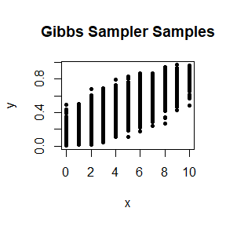

```r
# 可视化样本
plot(Rcpp_results[,1], Rcpp_results[,2], main = "Gibbs Sampler Samples", xlab = "x", ylab = "y", pch = 20)
```

##### Step2:撰写R函数

```r
# Gibbs sampler function
r_gibbs_sampler <- function(n, a, b ,num_samples, burn_in) {
  # Initialize vectors to store samples
  x_samples <- numeric(num_samples)
  y_samples <- numeric(num_samples)

  # Initial values
  x_samples[1] <- sample(0:n,1)
  y_samples[1] <- runif(1)  # Starting with a reasonable value for y

  for (i in 2:num_samples) {
    # Sample x given y
    y_current <- y_samples[i - 1]
    x_samples[i] <- rbinom(1, n, y_current)

    # Sample y given x
    x_current <- x_samples[i]
    alpha <- x_current + a
    beta <- n - x_current + b
    y_samples[i] <- rbeta(1, alpha, beta)
  }

  return(data.frame(X = x_samples[-(1:burn_in)], Y = y_samples[-(1:burn_in)]))
}
```

```r
R_results <- r_gibbs_sampler(n, a, b, num_samples, burn_in)

# 检查生成的样本
head(R_results)
```

```
##   X         Y
## 1 3 0.4204349
## 2 5 0.4120563
## 3 4 0.4388138
## 4 2 0.3516701
## 5 4 0.4312922
## 6 4 0.3629821
```

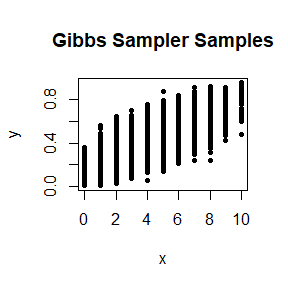

```r
# 可视化样本
plot(R_results[,1], R_results[,2], main = "Gibbs Sampler Samples", xlab = "x", ylab = "y", pch = 20)
```

##### Step3:使用qqplot比较两种Gibbs采样方法

[figure not shown]

```r
# Q-Q 图比较
par(mfrow = c(1, 2)) # 设置图形布局为 1 行 2 列
qqplot(R_results[, 1], Rcpp_results[, 1],
       main = "QQ Plot of R vs Rcpp (X)",,xlab = 'R',ylab = 'Rcpp')
abline(0, 1, col = "red")
qqplot(R_results[, 2], Rcpp_results[, 2],
       main = "QQ Plot of R vs Rcpp (Y)",,xlab = 'R',ylab = 'Rcpp')
abline(0, 1, col = "blue")
```

从上面的Q-Q图可以看出，图上的点接近对角线，说明用R函数和Rcpp产生的随机数分布一致。

##### Step4:比较两种方式的计算时间

```r
# 性能比较
library(microbenchmark)
ts <- microbenchmark(gibbsR=r_gibbs_sampler(n, a, b, num_samples, burn_in),gibbsRcpp=gibbs_sampler(n, a, b, num_samples, burn_in))
summary(ts)[,c(1,3,5,6)]
```

```
##        expr      lq   median       uq
## 1    gibbsR 11.1355 12.06695 13.52800
## 2 gibbsRcpp  1.2086  1.22530  1.35785
```

从上面的结果可以看出，Rcpp撰写的Gibbs抽样算法具有更快的运行速度。

#### Conclusion

##### Step5:对上面的结果给出总结

- Rcpp与R相比在效果上区别不大，都可以很好的完成任务
- Rcpp与R相比具有更快的运行速度，如在本例中其速度接近R函数的10倍
- Rcpp的开发成本更高，一般撰写比R函数更加困难一些